# STATISTICAL COMPUTING FINAL PROJECT

Kıymet Deren TOY

June 7, 2021

# 1 Introduction - Dataset 1

In this project, a total of 3 data sets will be examined. These datasets include social issues. Each dataset contains year information. Using this year’s information, the impact of the pandemic on individual issues will be mentioned.

The first data set includes the support of hot meals, soup, pita and food to people living in İzmir. It is a matter of curiosity whether these aids increase during the pandemic.

## 1.1 Libraries

```r
# library(ggplot2)
# library(MASS)
# library(ggpubr)
# library(Hmisc)
# library(dplyr)
# library(readxl)
# library(RColorBrewer)
# library(nortest)
```

## 1.2 Load Dataset 1

```r
mydata = read_excel("asevleri-yemek-yardimi.xlsx")
mydata <- mutate(mydata, TOPLAM_YARDIM = VERILEN_YEMEK_SAYISI +  VERILEN_KUMANYA_SAYISI + VERILEN_PIDE_SAYISI + VERILEN_CORBA_SAYISI)
```

## 1.3 Simple Summary

```r
summary(mydata)
```

```
##       YIL             AY         VERILEN_YEMEK_SAYISI VERILEN_KUMANYA_SAYISI
##  Min.   :2007   Min.   : 1.000   Min.   : 38704       Min.   : 4200
##  1st Qu.:2010   1st Qu.: 3.000   1st Qu.: 98033       1st Qu.: 8255
##  Median :2013   Median : 6.000   Median :114262       Median :10640
##  Mean   :2013   Mean   : 6.418   Mean   :124607       Mean   :13618
##  3rd Qu.:2017   3rd Qu.: 9.000   3rd Qu.:141827       3rd Qu.:16195
##  Max.   :2020   Max.   :12.000   Max.   :361690       Max.   :90585
##  VERILEN_PIDE_SAYISI VERILEN_CORBA_SAYISI TOPLAM_YARDIM
##  Min.   :    0       Min.   :    0        Min.   : 50235
##  1st Qu.:    0       1st Qu.:    0        1st Qu.:132197
##  Median :52160       Median :    0        Median :179292
##  Mean   :41925       Mean   : 5159        Mean   :185310
##  3rd Qu.:61815       3rd Qu.:11500        3rd Qu.:226015
##  Max.   :96213       Max.   :28232        Max.   :454674
```

## 1.4 General Information About TOPLAM_YARDIM

```r
mydata %>% summarise("Mean"=mean(mydata$TOPLAM_YARDIM), "Median"=median(mydata$TOPLAM_YARDIM), "Standart Deviation"=sd(mydata$TOPLAM_YARDIM),"Variation"=var(mydata$TOPLAM_YARDIM),"Max"=max(mydata$TOPLAM_YARDIM),"Minimum"=min(mydata$TOPLAM_YARDIM),"IQR"=IQR(mydata$TOPLAM_YARDIM))
```

```
## # A tibble: 1 x 7
##      Mean Median `Standart Deviation`   Variation    Max Minimum   IQR
##     <dbl>  <dbl>                <dbl>       <dbl>  <dbl>   <dbl> <dbl>
## 1 185310. 179292               70648. 4991166302. 454674   50235 93818
```

# 2 Data Visualization - Dataset 1

## 2.1 Histograms

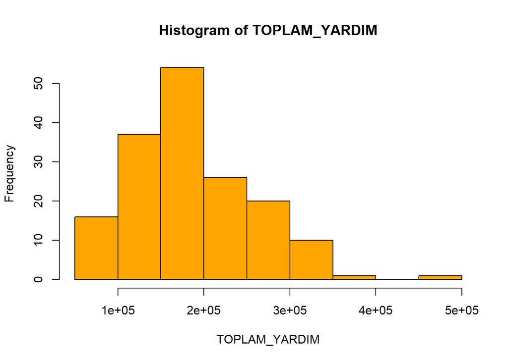

```r
hist(mydata$TOPLAM_YARDIM, main = "Histogram of TOPLAM_YARDIM",xlab = "TOPLAM_YARDIM" ,col="orange")
```

## 2.2 Month Distribution

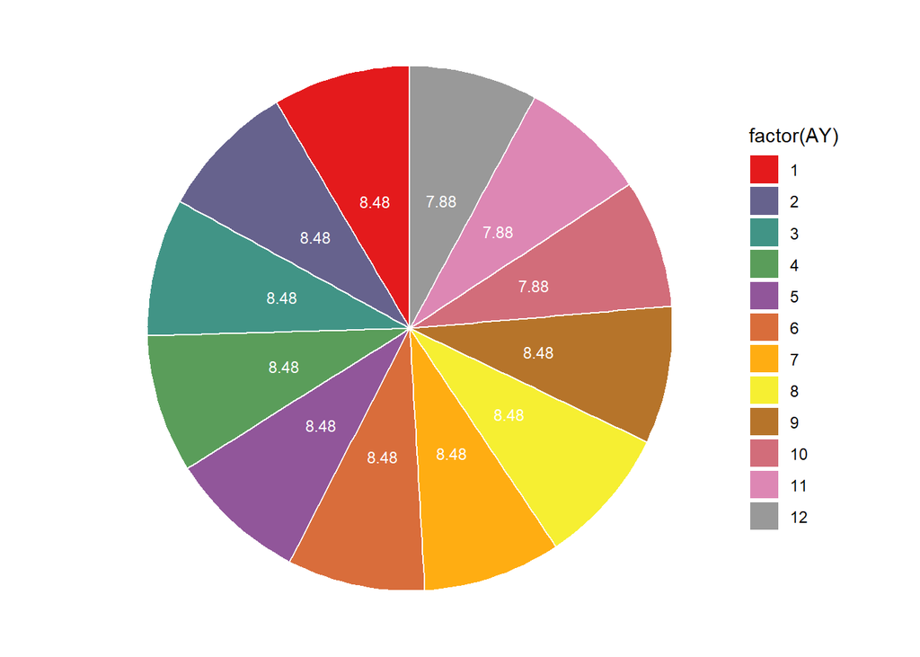

```r
month_percentage=mydata %>% count(AY)
month_percentage <- month_percentage %>%
  arrange(desc(AY)) %>%
  mutate(prop = format(round(n / sum(month_percentage$n) *100, 2), nsmall = 2)) %>%
  mutate(ypos = cumsum(n)- 0.5*n )

 getPalette = colorRampPalette(brewer.pal(9, "Set1"))
 colourCount = length(unique(mydata$AY))

ggplot(month_percentage, aes(x="", y=n, fill=factor(AY))) +
  geom_bar(stat="identity", width=1, color="white") +
  coord_polar("y", start=0) +
  theme_void() +
  geom_text(aes(y = ypos, label = prop), color = "white", size=3) +
  scale_fill_manual(values = getPalette(colourCount))
```

From the pie chart above, we can see that the municipality regularly provides aid every month. The low in 10,11,12 months is due to the missing part of the data set.

## 2.3 Year Distribution

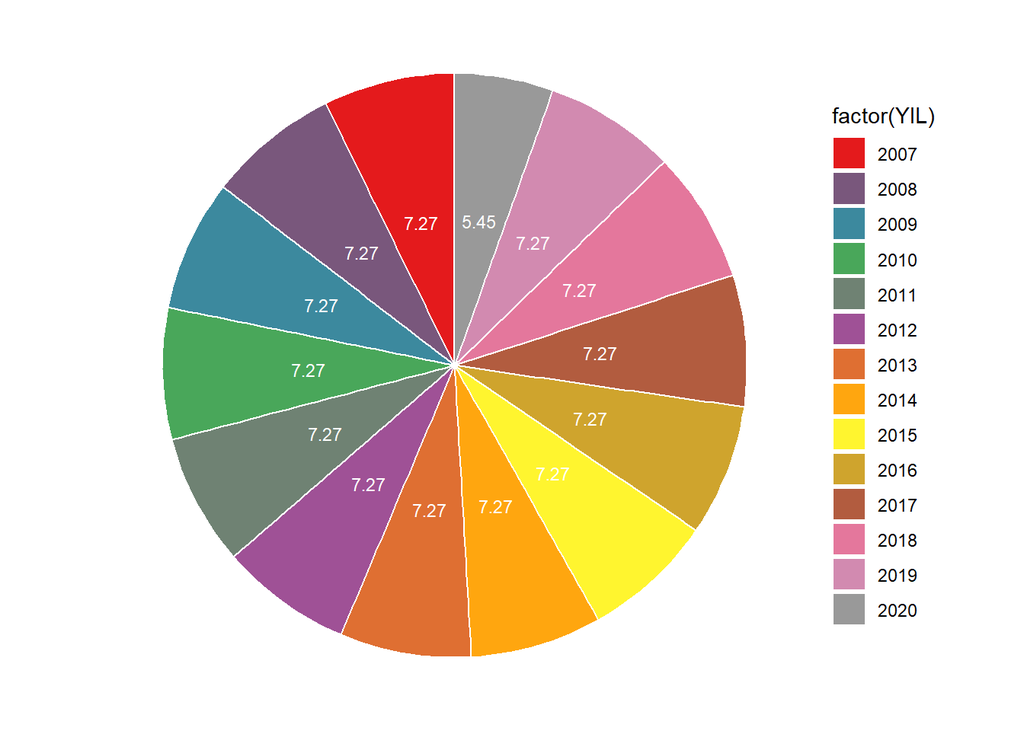

```r
year_percentage=mydata %>% count(YIL)
year_percentage <- year_percentage %>%
  arrange(desc(YIL)) %>%
  mutate(prop = format(round(n / sum(year_percentage$n) *100, 2), nsmall = 2)) %>%
  mutate(ypos = cumsum(n)- 0.5*n )

 getPalette = colorRampPalette(brewer.pal(9, "Set1"))
 colourCount = length(unique(mydata$YIL))

ggplot(year_percentage, aes(x="", y=n, fill=factor(YIL))) +
  geom_bar(stat="identity", width=1, color="white") +
  coord_polar("y", start=0) +
  theme_void() +
  geom_text(aes(y = ypos, label = prop), color = "white", size=3) +
  scale_fill_manual(values = getPalette(colourCount))
```

From the pie chart above, we can see that the municipality regularly provides aid every year. The low in 2020 year is due to the missing part of the data set.

# 3 Analysis - Dataset 1

## 3.1 Distributions

### 3.1.1 Means Differences Between Months According to TOPLAM_YARDIM

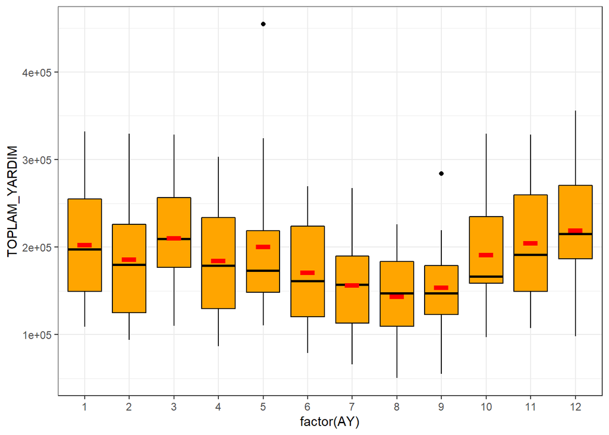

```r
ggplot(mydata,aes(x=factor(AY),y=TOPLAM_YARDIM))+
  geom_boxplot(fill="orange",colour="black")+
  stat_summary(fun=mean, geom="point",shape="-" ,fill="red" , size=15, color="red")+
  theme_bw()
```

In the graphic above, the red lines represent the average of the aids of those at the months. In general, a close distribution is observed. Outlier spots were detected in the ninth and fifth months.

### 3.1.2 Means Differences Between Years According to TOPLAM_YARDIM

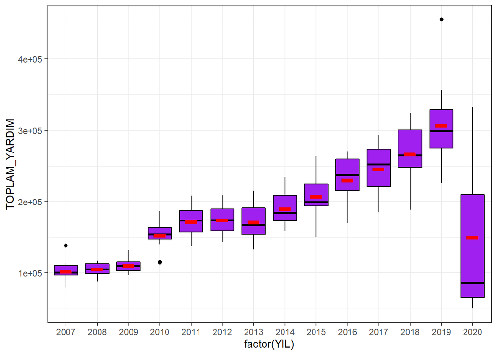

```r
ggplot(mydata,aes(x=factor(YIL),y=TOPLAM_YARDIM))+
  geom_boxplot(fill="purple",colour="black")+
  stat_summary(fun=mean, geom="point",shape="-" ,fill="red" , size=15, color="red")+
  theme_bw()
```

In the graphic above, the red lines represent the average of the aids of those at the years. When we look at the distribution and averages of years, we can see that the aid provided in 2020 is not more than in other years.

### 3.1.3 Means Differences Between Months According to VERILEN_CORBA_SAYISI

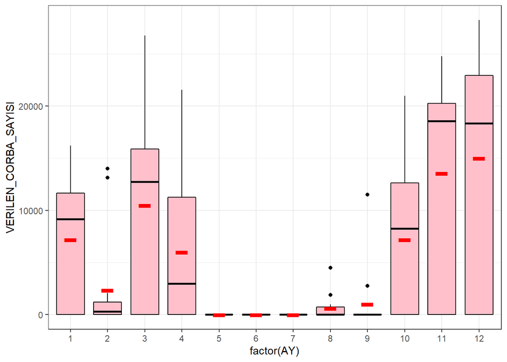

```r
ggplot(mydata,aes(x=factor(AY),y=VERILEN_CORBA_SAYISI))+
  geom_boxplot(fill="pink",colour="black")+
  stat_summary(fun=mean, geom="point",shape="-" ,fill="red" , size=15, color="red")+
  theme_bw()
```

From the graph above, it is possible to say that the soups given in the summer months are very few, almost 0. In addition, outlier spots are observed in the second, eighth and ninth months.

# 4 Confidance Intervals - Dataset 1

## 4.1 Confidance Interval of TOPLAM_YARDIM

```r
sample.mean <- mean(mydata$TOPLAM_YARDIM)
sample.n <- length(mydata$TOPLAM_YARDIM)
sample.sd <- sd(mydata$TOPLAM_YARDIM)
sample.se <- sample.sd/sqrt(sample.n)
alpha = 0.05
degrees.freedom = sample.n - 1
t.score = qt(p=alpha/2, df=degrees.freedom,lower.tail=F)
margin.error <- t.score * sample.se
lower.bound <- sample.mean - margin.error
upper.bound <- sample.mean + margin.error
print(c(lower.bound,upper.bound))
```

```
## [1] 174449.7 196169.4
```

As a result of the calculations, it was observed that the confidence intervals were 174449.7 and 196169.4.

## 4.2 Confidance Interval Between Years

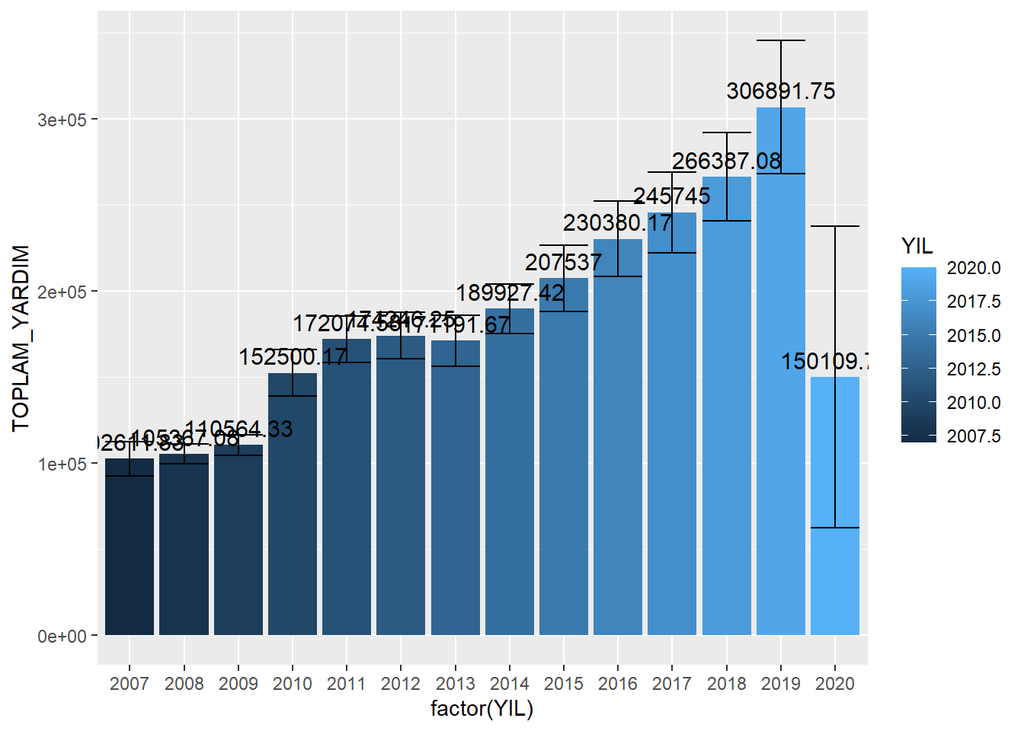

```r
ggplot(mydata, aes(factor(YIL), TOPLAM_YARDIM, fill=YIL)) +
    stat_summary(fun = mean, geom = "bar") +
    stat_summary(aes(label=round(..y..,2)), fun=mean, geom="text", size=4, vjust = -0.5) +
    stat_summary(fun.data = mean_cl_normal, geom = "errorbar")
```

When we look at the graph above, it is observed that the confidence interval of the aids in 2020 is much higher than the others. More consistent information can be provided with years other than 2020.

## 4.3 Confidance Interval Between Months according to VERILEN_CORBA_SAYISI

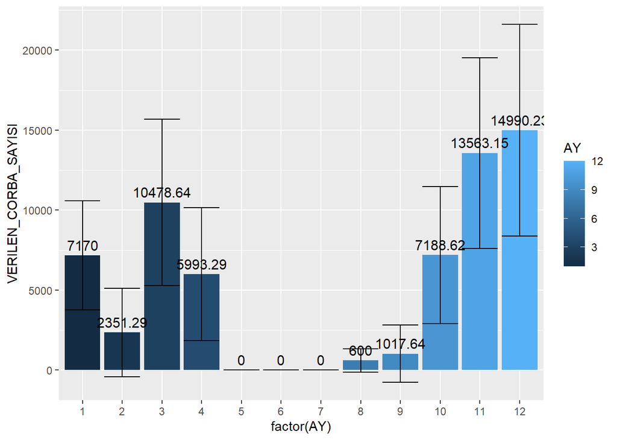

```r
ggplot(mydata, aes(factor(AY), VERILEN_CORBA_SAYISI, fill=AY)) +
    stat_summary(fun = mean, geom = "bar") +
    stat_summary(aes(label=round(..y..,2)), fun=mean, geom="text", size=4, vjust = -0.5) +
    stat_summary(fun.data = mean_cl_normal, geom = "errorbar")
```

When we look at the graph, it is observed that the confidence interval of the given soups at 12, 11 and 3 months are much higher than the others. Also, the given soups at 5, 6 and 7 months are 0. So, more consistent information can be provided with months other than these.

# 5 Normalization - Dataset 1

## 5.1 Normalize TOPLAM_YARDIM

Normalizing the TOPLAM_YARDIM column before starting hypothesis testing.

### 5.1.1 Normality test for TOPLAM_YARDIM

```r
shapiro.test(mydata$TOPLAM_YARDIM) #  p-value = 0.0007329 -> it is too bad
```

```
##
##  Shapiro-Wilk normality test
##
## data:  mydata$TOPLAM_YARDIM
## W = 0.96801, p-value = 0.0007329
```

### 5.1.2 Log Transformation

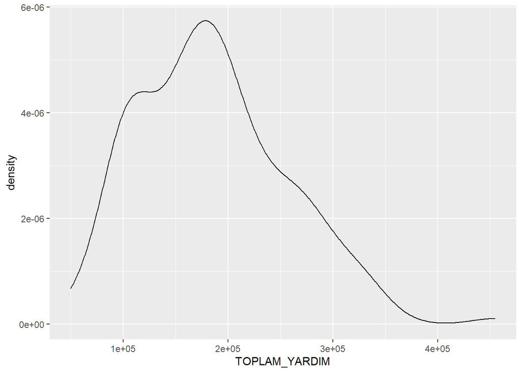

```r
mydata %>%
  ggplot(aes(x = TOPLAM_YARDIM)) +
  geom_density()
```

It would be good to do a log transformation as the data is skewed.

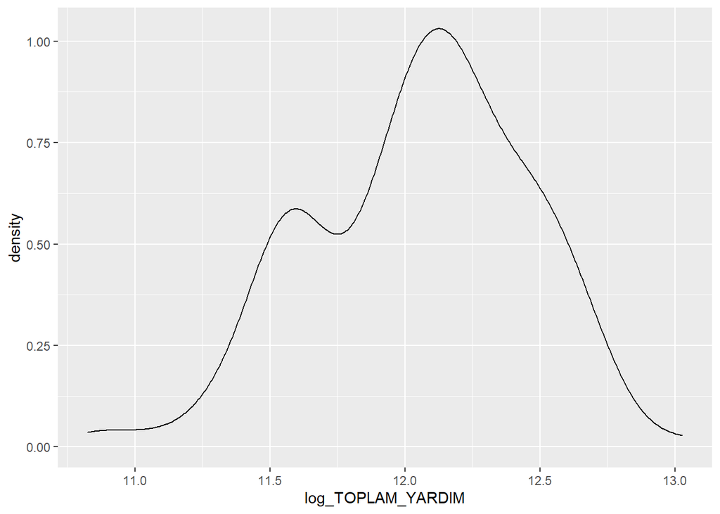

```r
mydata <- mydata %>%
  mutate(log_TOPLAM_YARDIM = log(TOPLAM_YARDIM))

# New graph
mydata %>%
  ggplot(aes(x = log_TOPLAM_YARDIM)) +
  geom_density()
```

### 5.1.3 Normality test for log_TOPLAM_YARDIM

```r
shapiro.test(mydata$log_TOPLAM_YARDIM) # p-value = 0.02492
```

```
##
##  Shapiro-Wilk normality test
##
## data:  mydata$log_TOPLAM_YARDIM
## W = 0.98127, p-value = 0.02492
```

Let’s do outlier detection and delete these points to bring the data closer to normal.

### 5.1.4 Outlier Detection

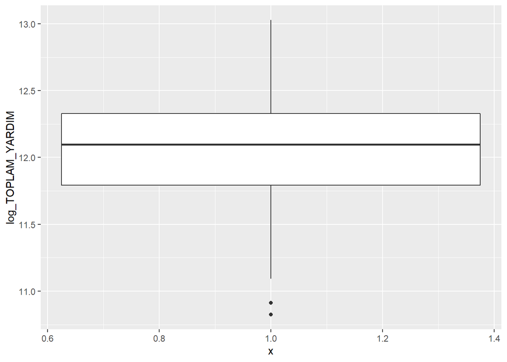

```r
mydata %>%
  ggplot(aes(x = 1, y = log_TOPLAM_YARDIM)) +
  geom_boxplot()
```

```r
new_data <- mydata %>%
  mutate(uc_deger = log_TOPLAM_YARDIM < 11 )

new_data <- new_data[-c(164,165), ]
```

Now our dataset is called new_data and we will use this dataset for the outlier deleted version.

### 5.1.5 Normality test for new_data$log_TOPLAM_YARDIM

```r
shapiro.test(new_data$log_TOPLAM_YARDIM) #p-value = 0.03293
```

```
##
##  Shapiro-Wilk normality test
##
## data:  new_data$log_TOPLAM_YARDIM
## W = 0.98205, p-value = 0.03293
```

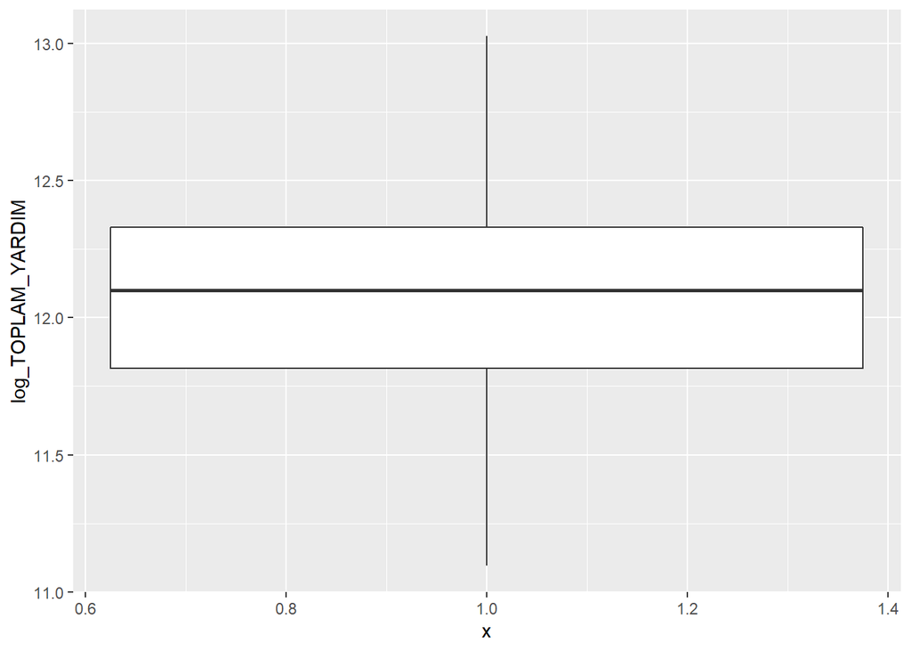

```r
# Box plot
new_data %>%
  filter(!uc_deger) %>%
  ggplot(aes(x = 1, y = log_TOPLAM_YARDIM)) +
  geom_boxplot()
```

# 6 Hypothesis Tests - Dataset 1

## 6.1 Are there significant difference between mean TOPLAM_YARDIM of 2007 and 2020 years?

**H0:** There is no significant difference between mean TOPLAM_YARDIM of 2007 and 2020 years.

**H1:** There is significant difference between mean TOPLAM_YARDIM of 2007 and 2020 years.

```r
# Before normalizing
t.test(mydata$TOPLAM_YARDIM[mydata$YIL==2007],mydata$TOPLAM_YARDIM[mydata$YIL==2020], data = mydata, var.equal = TRUE)  #p-value = 0.1667 > 0.05 fail to reject
```

```
##
##  Two Sample t-test
##
## data:  mydata$TOPLAM_YARDIM[mydata$YIL == 2007] and mydata$TOPLAM_YARDIM[mydata$YIL == 2020]
## t = -1.4381, df = 19, p-value = 0.1667
## alternative hypothesis: true difference in means is not equal to 0
## 95 percent confidence interval:
##  -116629.22   21633.33
## sample estimates:
## mean of x mean of y
##  102611.8  150109.8
```

```r
# After log transformation
t.test(mydata$log_TOPLAM_YARDIM[mydata$YIL==2007],mydata$log_TOPLAM_YARDIM[mydata$YIL==2020], data = mydata, var.equal = TRUE)  #p-value = p-value = 0.5268 > 0.05 fail to reject
```

```
##
##  Two Sample t-test
##
## data:  mydata$log_TOPLAM_YARDIM[mydata$YIL == 2007] and mydata$log_TOPLAM_YARDIM[mydata$YIL == 2020]
## t = -0.64473, df = 19, p-value = 0.5268
## alternative hypothesis: true difference in means is not equal to 0
## 95 percent confidence interval:
##  -0.5966966  0.3156582
## sample estimates:
## mean of x mean of y
##  11.52872  11.66924
```

```r
# After Outlier and Log Transformation
t.test(new_data$log_TOPLAM_YARDIM[new_data$YIL==2007],new_data$log_TOPLAM_YARDIM[new_data$YIL==2020], data = new_data, var.equal = TRUE) #  p-value = 0.08165 > 0.05 fail to reject
```

```
##
##  Two Sample t-test
##
## data:  new_data$log_TOPLAM_YARDIM[new_data$YIL == 2007] and new_data$log_TOPLAM_YARDIM[new_data$YIL == 2020]
## t = -1.8508, df = 17, p-value = 0.08165
## alternative hypothesis: true difference in means is not equal to 0
## 95 percent confidence interval:
##  -0.79004942  0.05166596
## sample estimates:
## mean of x mean of y
##  11.52872  11.89791
```

As I was curious about this hypothesis test, I applied 3 different t-tests using the formats of the data before normalization, after the log transform, and finally, the outliers were deleted. p value = 0.1667 before normalization p-value = 0.5268 after log transform p-value = 0.08165 after deleting the Outliers

Since every p-value here is greater than the significance level alpha, we fail in rejecting H0. Also, that the confidence interval value covers 0 shows that we will fail while rejecting H0. We can conclude that 2007 year’s total help is not significantly different from 2020 year’s average total help while p-value is greater than 0.05.

## 6.2 Is there a significant difference between the soups given in winter and summer?

**H0:** There is no significant difference between the soups given in winter and summer.

**H1:** There is significant difference between the soups given in winter and summer.

```r
winter = subset(new_data, subset = new_data$AY == "12" | new_data$AY == "1" |  new_data$AY == "2" )
summer = subset(new_data, subset = new_data$AY == "6" | new_data$AY == "7" |  new_data$AY == "8" )
t.test(winter$VERILEN_CORBA_SAYISI,summer$VERILEN_CORBA_SAYISI, var.equal = TRUE) # p-value = 4.545e-07
```

```
##
##  Two Sample t-test
##
## data:  winter$VERILEN_CORBA_SAYISI and summer$VERILEN_CORBA_SAYISI
## t = 5.4932, df = 80, p-value = 4.545e-07
## alternative hypothesis: true difference in means is not equal to 0
## 95 percent confidence interval:
##   4973.761 10624.824
## sample estimates:
## mean of x mean of y
##  8004.171   204.878
```

The p-value of the test is 4.545e-07, which is less than the significance level alpha = 0.05. We can reject H0, in other words the case that there is no significant difference between winter and summer with p-value 4.545e-07. In the box plot, which shows the soups given according to the months above, it can be easily seen that there is such a difference.

# 7 Anova Part - Dataset 1

## 7.1 Do the total number of aids change according to years?

**H0:** The total number of aids do not change according to years.

**H0:** µ1 = µ2 = µ3 = µ4 = µ5 = µ6 = µ7 = µ8 = µ9 = µ10 = µ11 = µ12 = µ13 = µ14

**H1:** The µ<sub>i</sub> are not all equal.

First, let’s check if the data is categorical and draw a graph.

```r
new_data$YIL = as.factor(new_data$YIL)
is.factor(new_data$YIL) #true
```

```
## [1] TRUE
```

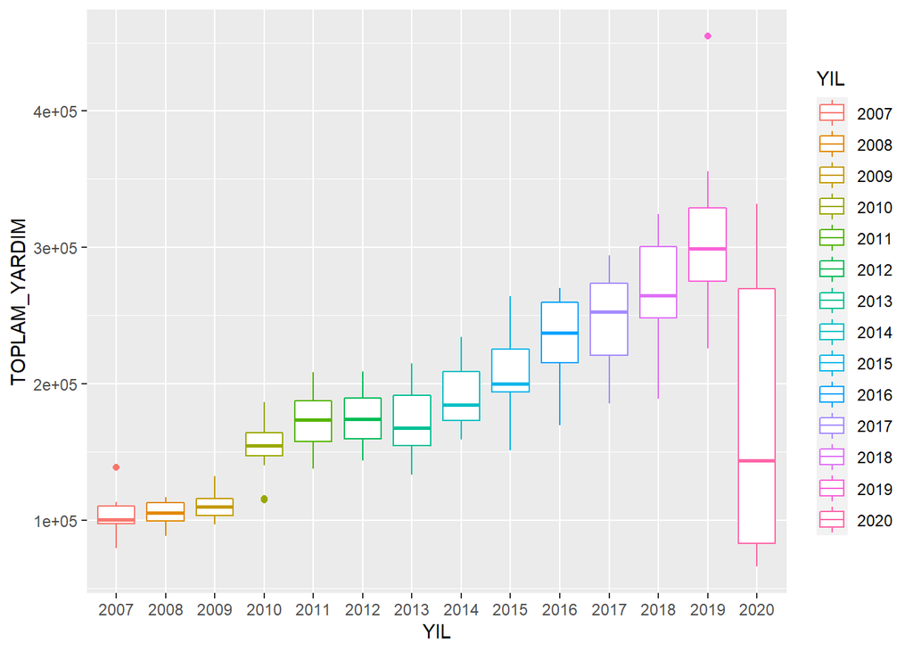

```r
ggplot(new_data, aes(YIL,TOPLAM_YARDIM))+geom_boxplot(aes(col=YIL))
```

**Anova test:**

```r
model1 = aov(new_data$TOPLAM_YARDIM ~ new_data$YIL)
summary(model1)
```

```
##               Df    Sum Sq   Mean Sq F value Pr(>F)
## new_data$YIL  13 5.753e+11 4.425e+10   31.76 <2e-16 ***
## Residuals    149 2.076e+11 1.393e+09
## ---
## Signif. codes:  0 '***' 0.001 '**' 0.01 '*' 0.05 '.' 0.1 ' ' 1
```

It was observed that the f-statistic was 31.76 and the corresponding p-value was quite significant since it was much less than the significance level. Therefore, it would be wise to reject the H0 hypothesis, which says that the total number of aids made in all years is equal. In other words, the total aid in 14 years is not equal. We apply the Tukey test to understand in which years there is a significant difference.

**Tukey Test:** With this test, we detect variables that differ significantly.

```r
TukeyHSD(model1, conf.level = 0.95)
```

```
##   Tukey multiple comparisons of means
##     95% family-wise confidence level
##
## Fit: aov(formula = new_data$TOPLAM_YARDIM ~ new_data$YIL)
##
## $`new_data$YIL`
##                   diff         lwr        upr     p adj
## 2008-2007    2755.2500  -49206.105  54716.605 1.0000000
## 2009-2007    7952.5000  -44008.855  59913.855 0.9999996
## 2010-2007   49888.3333   -2073.022 101849.689 0.0737559
## 2011-2007   69462.7500   17501.395 121424.105 0.0008670
## 2012-2007   71634.4167   19673.061 123595.772 0.0004836
## 2013-2007   68579.8333   16618.478 120541.189 0.0010943
## 2014-2007   87315.5833   35354.228 139276.939 0.0000048
## 2015-2007  104925.1667   52963.811 156886.522 0.0000000
## 2016-2007  127768.3333   75806.978 179729.689 0.0000000
## 2017-2007  143133.1667   91171.811 195094.522 0.0000000
## 2018-2007  163775.2500  111813.895 215736.605 0.0000000
## 2019-2007  204279.9167  152318.561 256241.272 0.0000000
## 2020-2007   75366.8810   14833.734 135900.028 0.0029526
## 2009-2008    5197.2500  -46764.105  57158.605 1.0000000
## 2010-2008   47133.0833   -4828.272  99094.439 0.1192420
## 2011-2008   66707.5000   14746.145 118668.855 0.0017773
## 2012-2008   68879.1667   16917.811 120840.522 0.0010115
## 2013-2008   65824.5833   13863.228 117785.939 0.0022245
## 2014-2008   84560.3333   32598.978 136521.689 0.0000112
## 2015-2008  102169.9167   50208.561 154131.272 0.0000000
## 2016-2008  125013.0833   73051.728 176974.439 0.0000000
## 2017-2008  140377.9167   88416.561 192339.272 0.0000000
## 2018-2008  161020.0000  109058.645 212981.355 0.0000000
## 2019-2008  201524.6667  149563.311 253486.022 0.0000000
## 2020-2008   72611.6310   12078.484 133144.778 0.0052581
## 2010-2009   41935.8333  -10025.522  93897.189 0.2609017
## 2011-2009   61510.2500    9548.895 113471.605 0.0063892
## 2012-2009   63681.9167   11720.561 115643.272 0.0037900
## 2013-2009   60627.3333    8665.978 112588.689 0.0078584
## 2014-2009   79363.0833   27401.728 131324.439 0.0000539
## 2015-2009   96972.6667   45011.311 148934.022 0.0000002
## 2016-2009  119815.8333   67854.478 171777.189 0.0000000
## 2017-2009  135180.6667   83219.311 187142.022 0.0000000
```

[output cut: 43 more lines]

```
## 2016-2015   22843.1667  -29118.189  74804.522 0.9658816
## 2017-2015   38208.0000  -13753.355  90169.355 0.4102657
## 2018-2015   58850.0833    6888.728 110811.439 0.0118044
## 2019-2015   99354.7500   47393.395 151316.105 0.0000001
## 2020-2015  -29558.2857  -90091.433  30974.861 0.9246222
## 2017-2016   15364.8333  -36596.522  67326.189 0.9991669
## 2018-2016   36006.9167  -15954.439  87968.272 0.5119353
## 2019-2016   76511.5833   24550.228 128472.939 0.0001236
## 2020-2016  -52401.4524 -112934.599   8131.695 0.1682942
## 2018-2017   20642.0833  -31319.272  72603.439 0.9854193
## 2019-2017   61146.7500    9185.395 113108.105 0.0069602
## 2020-2017  -67766.2857 -128299.433  -7233.139 0.0137437
## 2019-2018   40504.6667  -11456.689  92466.022 0.3139416
## 2020-2018  -88408.3690 -148941.516 -27875.222 0.0001477
## 2020-2019 -128913.0357 -189446.183 -68379.889 0.0000000
```

When we look at the pairs in general, we can say that there is a significant difference between them. For example: 2011-2007.

# 8 Introduction - Dataset 2

The second data set includes the records in children and youth centers in İzmir. It is possible to reach the total number of children coming to these centers and the number of children receiving psychological support in these centers. It is a matter of curiosity whether the number of students receiving psychological support in these centers has increased with the pandemic in 2020.

## 8.1 Load Dataset 2

```r
mydata2 = read.csv("cocuk-ve-genclik-merkezi.csv",encoding="UTF-8")
mydata2 <- mutate(mydata2, Toplam.yardım.alan.çocuk.sayısı = Psikolojik.Danışmanlık.Alan.Kız.Çocuk.Sayısı  + Psikolojik.Danışmanlık.Alan.Oğlan.Çocuk.Sayısı )
```

## 8.2 Simple Summary About Dataset 2

```r
summary(mydata2)
```

```
##   X.U.FEFF._id        Yıl        Birim.Adı          Oğlan.Çocuk
##  Min.   : 1.00   Min.   :2013   Length:30          Min.   : 17.00
##  1st Qu.: 8.25   1st Qu.:2017   Class :character   1st Qu.: 54.25
##  Median :15.50   Median :2018   Mode  :character   Median :111.50
##  Mean   :15.50   Mean   :2018                      Mean   :129.40
##  3rd Qu.:22.75   3rd Qu.:2019                      3rd Qu.:171.50
##  Max.   :30.00   Max.   :2020                      Max.   :352.00
##
##    Oğlan.0.6       Oğlan.6.12      Oğlan.12.
##  Min.   : 0.00   Min.   : 15.0   Min.   :  0.00
##  1st Qu.: 0.00   1st Qu.: 47.0   1st Qu.:  5.50
##  Median : 0.00   Median : 87.5   Median : 17.50
##  Mean   :13.67   Mean   : 98.6   Mean   : 20.47
##  3rd Qu.:23.75   3rd Qu.:122.0   3rd Qu.: 25.00
##  Max.   :61.00   Max.   :262.0   Max.   :128.00
##
##  Psikolojik.Danışmanlık.Alan.Oğlan.Çocuk.Sayısı   Kız.Çocuk        Kız.0.6
##  Min.   :  0.00                                 Min.   : 22.0   Min.   : 0.00
##  1st Qu.:  1.50                                 1st Qu.: 61.0   1st Qu.: 0.00
##  Median :  9.00                                 Median :121.5   Median : 0.00
##  Mean   : 15.63                                 Mean   :145.1   Mean   :16.55
##  3rd Qu.: 17.50                                 3rd Qu.:185.8   3rd Qu.:36.00
##  Max.   :100.00                                 Max.   :420.0   Max.   :90.00
##                                                                 NA's   :1
##     Kız.6.12        Kız.12.      Psikolojik.Danışmanlık.Alan.Kız.Çocuk.Sayısı
##  Min.   : 21.0   Min.   : 0.00   Min.   :  0.00
##  1st Qu.: 44.5   1st Qu.: 6.00   1st Qu.:  1.25
##  Median : 94.0   Median :17.50   Median :  9.00
##  Mean   :110.7   Mean   :18.40   Mean   : 22.40
##  3rd Qu.:136.8   3rd Qu.:31.75   3rd Qu.: 14.00
##  Max.   :295.0   Max.   :44.00   Max.   :188.00
##
##   Okul.Öncesi        İlkokul          Ortaokul           Lise
##  Min.   :  0.00   Min.   : 29.00   Min.   :  5.00   Min.   : 0.0
##  1st Qu.:  0.00   1st Qu.: 61.25   1st Qu.: 47.50   1st Qu.: 0.0
##  Median :  0.00   Median :127.00   Median : 86.50   Median : 1.0
##  Mean   : 26.63   Mean   :151.47   Mean   : 94.33   Mean   : 2.2
##  3rd Qu.: 52.50   3rd Qu.:198.75   3rd Qu.:126.75   3rd Qu.: 3.0
##  Max.   :123.00   Max.   :397.00   Max.   :309.00   Max.   :12.0
##
##   Toplam.Çocuk       Kadın            X18.32           X33.45
##  Min.   : 43.0   Min.   :  0.00   Min.   : 0.000   Min.   :  0.00
##  1st Qu.:115.2   1st Qu.:  0.00   1st Qu.: 0.000   1st Qu.:  0.00
##  Median :235.5   Median :  6.00   Median : 0.000   Median :  0.50
##  Mean   :274.7   Mean   : 53.73   Mean   : 4.367   Mean   : 14.13
##  3rd Qu.:351.8   3rd Qu.: 55.00   3rd Qu.: 2.500   3rd Qu.: 13.25
##  Max.   :772.0   Max.   :448.00   Max.   :29.000   Max.   :106.00
##
##       X45.       Yetişkin.Toplam  Toplam.yardım.alan.çocuk.sayısı
##  Min.   : 0.00   Min.   :  0.00   Min.   :  0.00
##  1st Qu.: 0.00   1st Qu.:  0.00   1st Qu.:  2.75
##  Median : 0.00   Median :  6.00   Median : 21.00
##  Mean   : 4.10   Mean   : 53.87   Mean   : 38.03
##  3rd Qu.: 6.25   3rd Qu.: 56.50   3rd Qu.: 35.00
##  Max.   :21.00   Max.   :448.00   Max.   :280.00
##
```

# 9 Data Visualization - Dataset 2

## 9.1 Histograms

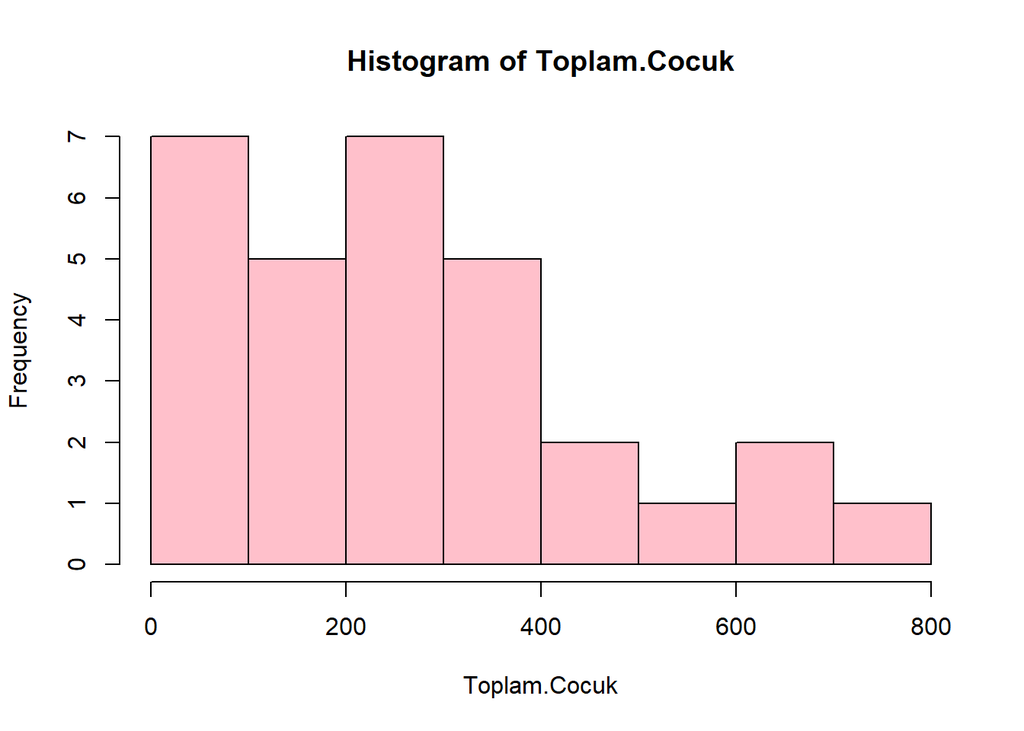

```r
hist(mydata2$Toplam.Çocuk, main = "Histogram of Toplam.Cocuk",xlab = "Toplam.Cocuk" ,col="pink")
```

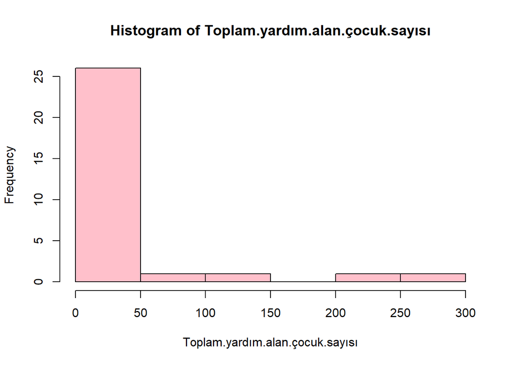

```r
hist(mydata2$Toplam.yardım.alan.çocuk.sayısı, main = "Histogram of Toplam.yardım.alan.çocuk.sayısı",xlab = "Toplam.yardım.alan.çocuk.sayısı" ,col="pink")
```

## 9.2 Male and Female Students Receiving Psychological Support

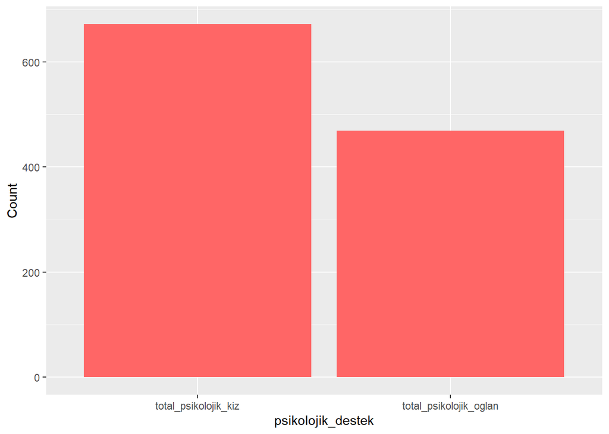

```r
total_psikolojik_kiz= c(sum(mydata2$Psikolojik.Danışmanlık.Alan.Kız.Çocuk.Sayısı))
total_psikolojik_oglan = c(sum(mydata2$Psikolojik.Danışmanlık.Alan.Oğlan.Çocuk.Sayısı))
total_psikolojik_destek = c(sum(total_psikolojik_kiz,total_psikolojik_oglan)) #1141


psikolojik_destek <- c("total_psikolojik_kiz","total_psikolojik_oglan")
df_person <- data.frame(
  psikolojik_destek,
  Count=c(total_psikolojik_kiz,total_psikolojik_oglan)
  )


ggplot(data=df_person, aes(x=psikolojik_destek,Count)) +
  geom_bar(stat="identity", fill = "#FF6666")
```

Looking at the graph, it is seen that there are more female students who receive psychological support.

## 9.3 Distribution of Students by School Levels

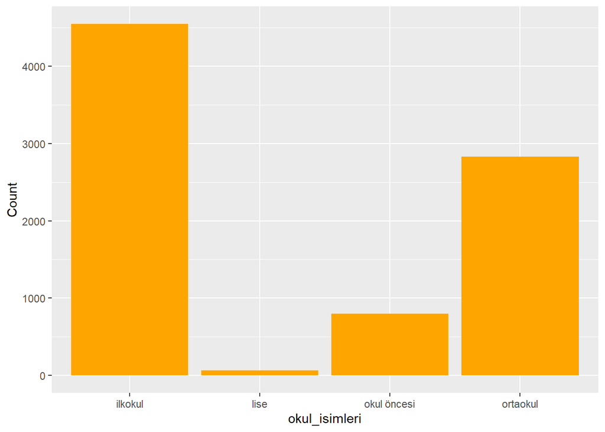

```r
okul.öncesi= c(sum(mydata2$Okul.Öncesi))
ilkokul= c(sum(mydata2$İlkokul))
ortaokul= c(sum(mydata2$Ortaokul))
lise= c(sum(mydata2$Lise))


okul_isimleri <- c("okul öncesi","ilkokul","ortaokul","lise")
df_okul <- data.frame(
  okul_isimleri,
  Count=c(okul.öncesi,ilkokul,ortaokul,lise)
  )


ggplot(data=df_okul, aes(x=okul_isimleri,Count)) +
  geom_bar(stat="identity", fill = "orange")
```

When we look at the graph, we can see that the students who come to the center are generally those who go to primary school.

## 9.4 District Distribution

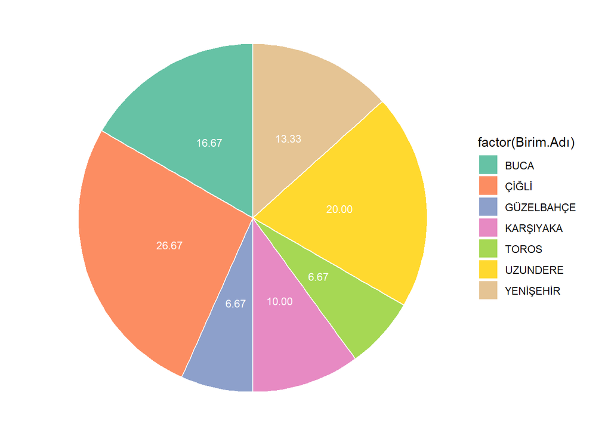

```r
birim_percentage=mydata2 %>% count(Birim.Adı)
birim_percentage <- birim_percentage %>%
  arrange(desc(Birim.Adı)) %>%
  mutate(prop = format(round(n / sum(birim_percentage$n) *100, 2), nsmall = 2)) %>%
  mutate(ypos = cumsum(n)- 0.5*n )

ggplot(birim_percentage, aes(x="", y=n, fill=factor(Birim.Adı))) +
  geom_bar(stat="identity", width=1, color="white") +
  coord_polar("y", start=0) +
  theme_void() +

  geom_text(aes(y = ypos, label = prop), color = "white", size=3) +
  scale_fill_brewer(palette="Set2")
```

When we look at the pie chart, we can see that there is more data on Çİğli and Uzundere.

## 9.5 Total number of children receiving aid by Birim_Adı

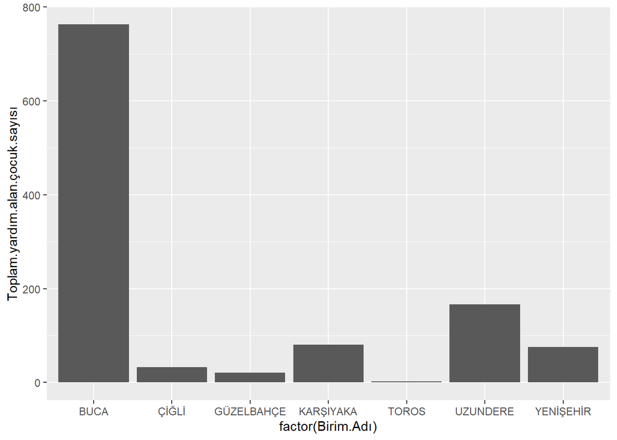

```r
ggplot(mydata2,aes(x=factor(Birim.Adı), y=Toplam.yardım.alan.çocuk.sayısı))+
  geom_bar(stat="identity")
```

The district that received the most psychological support is Buca. The least help was received in Toros.

# 10 Analysis - Dataset 2

## 10.1 Distributions

### 10.1.1 Means Differences Between Years According to Toplam.yardım.alan.çocuk.sayısı

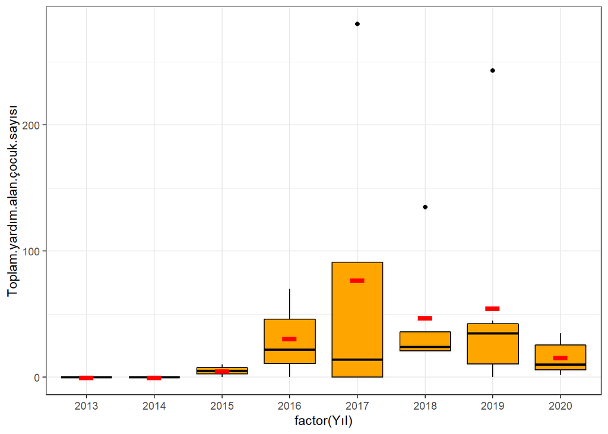

```r
ggplot(mydata2,aes(x=factor(Yıl),y=Toplam.yardım.alan.çocuk.sayısı))+
  geom_boxplot(fill="orange",colour="black")+
  stat_summary(fun=mean, geom="point",shape="-" ,fill="red" , size=15, color="red")+
  theme_bw()
```

It is seen that the number of children receiving aid was the highest in 2017. The pandemic in 2020 does not seem to have increased the number of children receiving support.

### 10.1.2 Means Differences Between Years According to Toplam.Cocuk

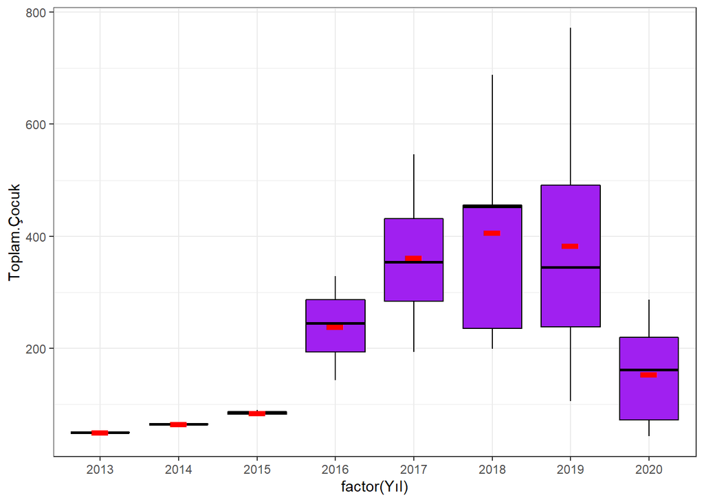

```r
ggplot(mydata2,aes(x=factor(Yıl),y=Toplam.Çocuk))+
  geom_boxplot(fill="purple",colour="black")+
  stat_summary(fun=mean, geom="point",shape="-" ,fill="red" , size=15, color="red")+
  theme_bw()
```

In 2020, there has been a decrease in the number of children coming to the center with the pandemic. This may be due to prohibitions for children.

# 11 Confidance Intervals - Dataset 2

## 11.1 Confidance Interval Between Years According to Toplam.Cocuk

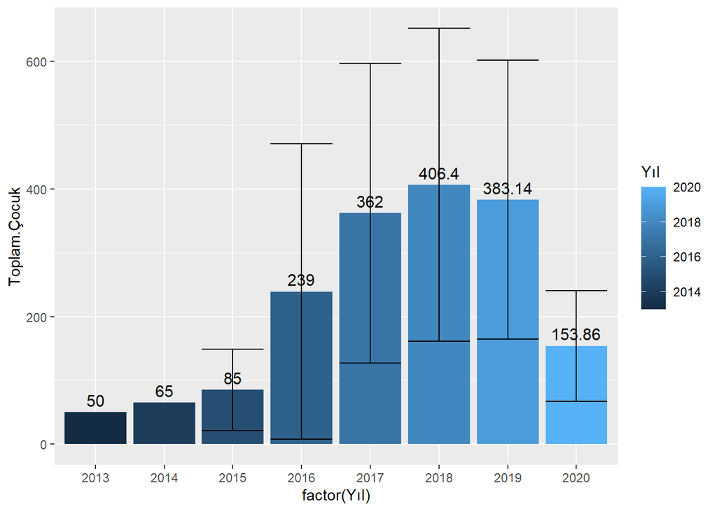

```r
ggplot(mydata2, aes(factor(Yıl), Toplam.Çocuk, fill=Yıl)) +
    stat_summary(fun = mean, geom = "bar") +
    stat_summary(aes(label=round(..y..,2)), fun=mean, geom="text", size=4, vjust = -0.5) +
    stat_summary(fun.data = mean_cl_normal, geom = "errorbar")
```

## 11.2 Confidance Interval Between Years according to Toplam.yardım.alan.çocuk.sayısı

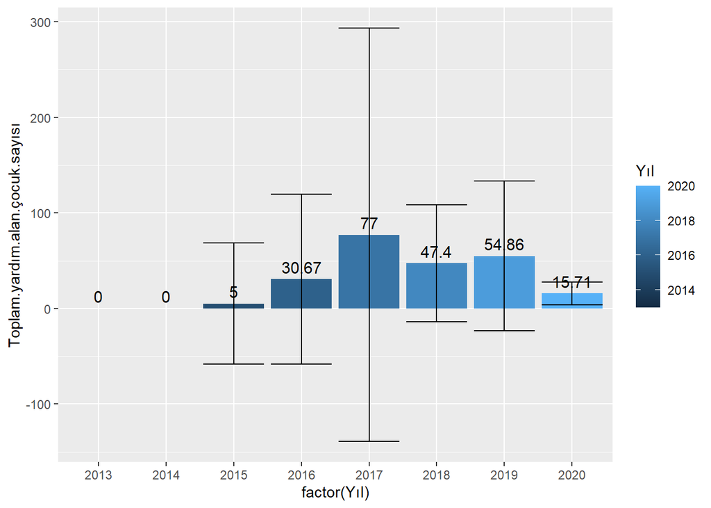

```r
ggplot(mydata2, aes(factor(Yıl), Toplam.yardım.alan.çocuk.sayısı, fill=Yıl)) +
    stat_summary(fun = mean, geom = "bar") +
    stat_summary(aes(label=round(..y..,2)), fun=mean, geom="text", size=4, vjust = -0.5) +
    stat_summary(fun.data = mean_cl_normal, geom = "errorbar")
```

The wide confidence interval in 2017 reduces our confidence in the data for that year.

# 12 Normalization - Dataset 2

## 12.1 Normalize to Toplam.yardım.alan.çocuk.sayısı

### 12.1.1 Normality test for Toplam.yardım.alan.çocuk.sayısı and Toplam.Çocuk

```r
shapiro.test(mydata2$Toplam.yardım.alan.çocuk.sayısı) #  p-value = 3.05e-08 -> very bad
```

```
##
##  Shapiro-Wilk normality test
##
## data:  mydata2$Toplam.yardım.alan.çocuk.sayısı
## W = 0.56818, p-value = 3.05e-08
```

```r
shapiro.test(mydata2$Toplam.Çocuk) #   p-value = 0.0142 -> eh
```

```
##
##  Shapiro-Wilk normality test
##
## data:  mydata2$Toplam.Çocuk
## W = 0.9092, p-value = 0.0142
```

Since it is below 0.05 in two values, it cannot be considered normal.

### 12.1.2 Log Transformation

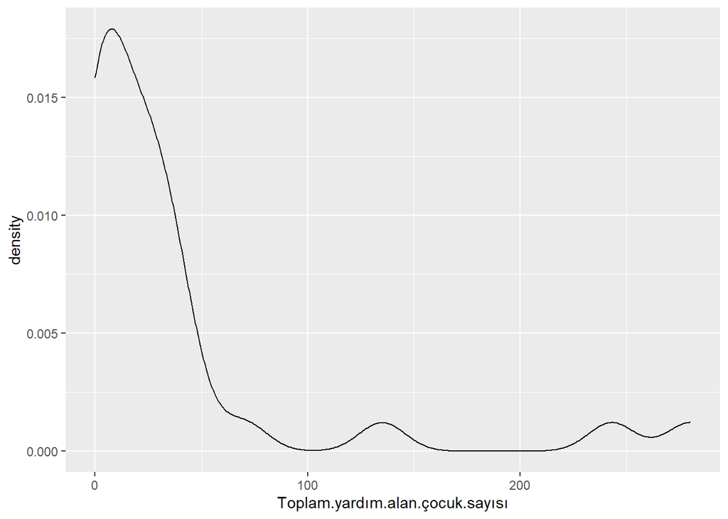

```r
mydata2 %>%
  ggplot(aes(x = Toplam.yardım.alan.çocuk.sayısı)) +
  geom_density()
```

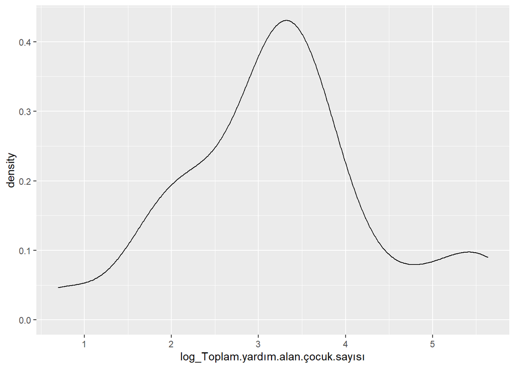

```r
mydata2 <- mydata2 %>%
  mutate(log_Toplam.yardım.alan.çocuk.sayısı = log(Toplam.yardım.alan.çocuk.sayısı))

# New graph
mydata2 %>%
  ggplot(aes(x = log_Toplam.yardım.alan.çocuk.sayısı)) +
  geom_density()
```

### 12.1.3 Outlier Detection

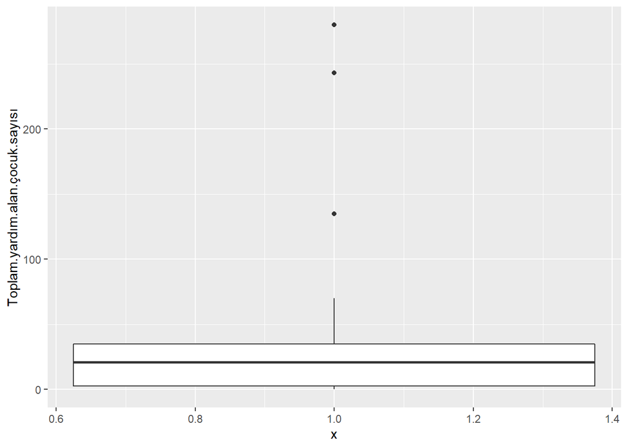

```r
mydata2 %>%
  ggplot(aes(x = 1, y = Toplam.yardım.alan.çocuk.sayısı)) +
  geom_boxplot()
```

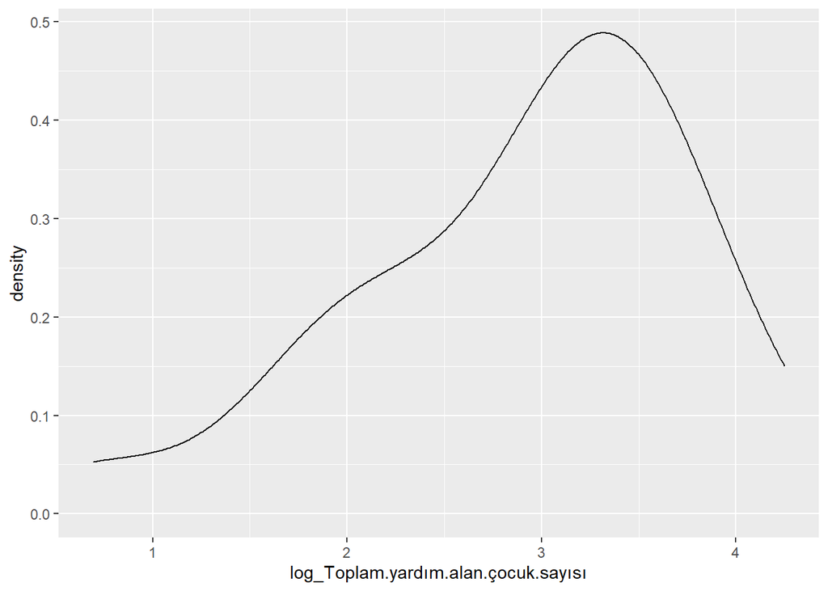

```r
new_data2 <- mydata2 %>%
  mutate(alt_deger = mydata2$Toplam.yardım.alan.çocuk.sayısı < 1 )

new_data2 <- new_data2 %>%
  mutate(uc_deger = mydata2$Toplam.yardım.alan.çocuk.sayısı > 100 )

new_data2 <- new_data2[-c(1,2,3,5,8,11,10,14,19,22), ]
new_data2 %>%
  ggplot(aes(x = log_Toplam.yardım.alan.çocuk.sayısı)) +
  geom_density()
```

After the outliers are deleted and the log transformation is applied, we run the normality test again.

### 12.1.4 Normality test for new_data2$log_Toplam.yardım.alan.çocuk.sayısı

```r
shapiro.test(new_data2$log_Toplam.yardım.alan.çocuk.sayısı) # p-value = 0.1822 -> very good
```

```
##
##  Shapiro-Wilk normality test
##
## data:  new_data2$log_Toplam.yardım.alan.çocuk.sayısı
## W = 0.93374, p-value = 0.1822
```

We have ensured that the p-value exceeds 0.05 by a certain percentage. From here on we will use the new_data2 dataset.

# 13 Hypothesis Tests - Dataset 2

## 13.1 Are there significant difference between mean log_Toplam.yardım.alan.çocuk.sayısı of 2019 and 2020 years?

```r
t.test(new_data2$log_Toplam.yardım.alan.çocuk.sayısı[new_data2$Yıl==2019],new_data2$log_Toplam.yardım.alan.çocuk.sayısı[new_data2$Yıl==2020], data = new_data2, var.equal = TRUE) #  p-value = 0.2019 > 0.05 fail to reject
```

```
##
##  Two Sample t-test
##
## data:  new_data2$log_Toplam.yardım.alan.çocuk.sayısı[new_data2$Yıl == 2019] and new_data2$log_Toplam.yardım.alan.çocuk.sayısı[new_data2$Yıl == 2020]
## t = 1.3658, df = 10, p-value = 0.2019
## alternative hypothesis: true difference in means is not equal to 0
## 95 percent confidence interval:
##  -0.4814496  2.0066074
## sample estimates:
## mean of x mean of y
##  3.127171  2.364593
```

The p-value of the test is 0.2019, which is more than the significance level alpha = 0.05. We can conclude that 2019’s average total number of children receiving assistance is not significantly different from 2020’s average total number of children receiving assistance with a p-value = 0.2019.

# 14 Anova Part - Dataset 2

## 14.1 Do the total number of children receiving psychological support change according to years?

**H0:** The total number of children receiving psychological support do not change according to years.

**H1:** The µ<sub>i</sub> are not all equal.

First, let’s check if the data is categorical and draw a graph.

```r
mydata2$Yıl = as.factor(mydata2$Yıl)
is.factor(mydata2$Yıl) #true
```

```
## [1] TRUE
```

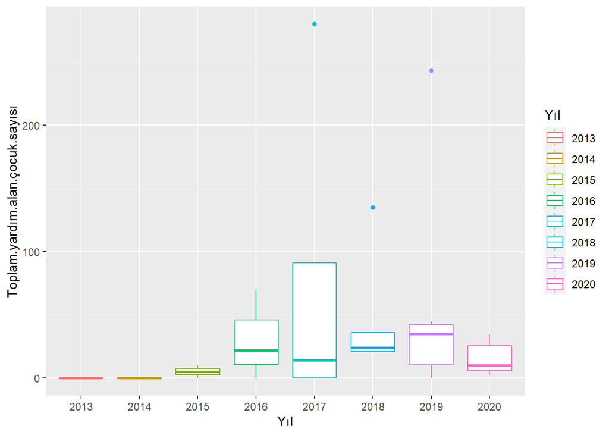

```r
ggplot(mydata2, aes(Yıl,Toplam.yardım.alan.çocuk.sayısı))+geom_boxplot(aes(col=Yıl))
```

**Anova test:**

```r
model2 = aov(mydata2$Toplam.yardım.alan.çocuk.sayısı ~ mydata2$Yıl)
summary(model2)
```

```
##             Df Sum Sq Mean Sq F value Pr(>F)
## mydata2$Yıl  7  17219    2460   0.484  0.836
## Residuals   22 111920    5087
```

The p value appears to be greater than 0.05 in the above ANOVA output. This indicates that we could not find a statistically significant result and we would not reject the H0 hypothesis. The unequal variances is one of the reasons why we cannot reject H0.

## 14.2 Do the total number of children receiving psychological support change according to Birim.Adı?

**H0:** µ1 = µ2 = µ3 = µ4 = µ5 = µ6 = µ7 **H1:** The µ<sub>i</sub> are not all equal.

First, let’s check if the data is categorical and draw a graph.

```r
mydata2$Birim.Adı = as.factor(mydata2$Birim.Adı)
is.factor(mydata2$Birim.Adı) #true
```

```
## [1] TRUE
```

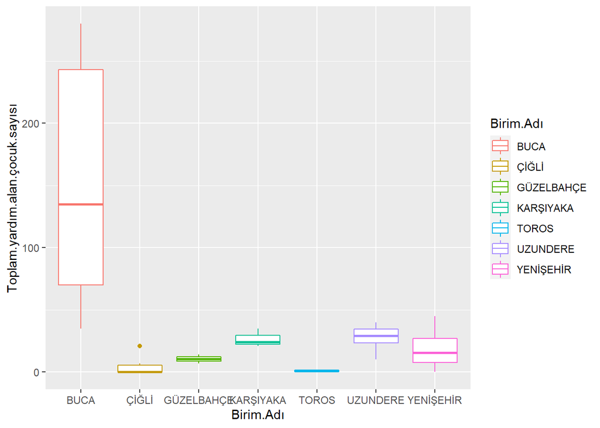

```r
ggplot(mydata2, aes(Birim.Adı,Toplam.yardım.alan.çocuk.sayısı))+geom_boxplot(aes(col=Birim.Adı))
```

**Anova test:**

```r
model5 = aov(mydata2$Toplam.yardım.alan.çocuk.sayısı ~ mydata2$Birim.Adı)
summary(model5)
```

```
##                   Df Sum Sq Mean Sq F value  Pr(>F)
## mydata2$Birim.Adı  6  81566   13594   6.573 0.00038 ***
## Residuals         23  47573    2068
## ---
## Signif. codes:  0 '***' 0.001 '**' 0.01 '*' 0.05 '.' 0.1 ' ' 1
```

The p-value value is below the significance level. There is significance here and it would be quite meaningful to reject the H0 hypothesis. In other words, the number of students receiving psychological support in certain units is not equal.

# 15 Introduction - Dataset 3

The third data set includes the social assistance applications made to the municipality in İzmir. It will be possible to search for answers to questions such as which gender people make the most applications, and for which support the most applications are made. In addition, it will be investigated whether these aid applications increase during the pandemic period.

## 15.1 Load Dataset 3

```r
mydata3 = read.csv("sosyal-yardim-basvurulari.csv",encoding="UTF-8")
```

## 15.2 Simple Summary About Data

```r
summary(mydata3)
```

```
##   X.U.FEFF._id       YIL       YARDIM_TALEBI      BASVURU_SEKLI
##  Min.   :   1   Min.   :2012   Length:9335        Length:9335
##  1st Qu.:2334   1st Qu.:2015   Class :character   Class :character
##  Median :4668   Median :2017   Mode  :character   Mode  :character
##  Mean   :4668   Mean   :2017
##  3rd Qu.:7002   3rd Qu.:2019
##  Max.   :9335   Max.   :2021
##  BASVURU_TIPI         CINSIYET         BASVURU_ADEDI
##  Length:9335        Length:9335        Min.   :    1.0
##  Class :character   Class :character   1st Qu.:    1.0
##  Mode  :character   Mode  :character   Median :    3.0
##                                        Mean   :  127.6
##                                        3rd Qu.:   12.0
##                                        Max.   :48136.0
```

## 15.3 General Information About BASVURU_ADEDI

```r
mydata3 %>% summarise("Mean"=mean(mydata3$BASVURU_ADEDI), "Median"=median(mydata3$BASVURU_ADEDI), "Standart Deviation"=sd(mydata3$BASVURU_ADEDI),"Variation"=var(mydata3$BASVURU_ADEDI),"Max"=max(mydata3$BASVURU_ADEDI),"Minimum"=min(mydata3$BASVURU_ADEDI),"IQR"=IQR(mydata3$BASVURU_ADEDI))
```

```
##       Mean Median Standart Deviation Variation   Max Minimum IQR
## 1 127.5738      3           1148.312   1318621 48136       1  11
```

# 16 Data Visualization - Dataset 3

## 16.1 Histogram

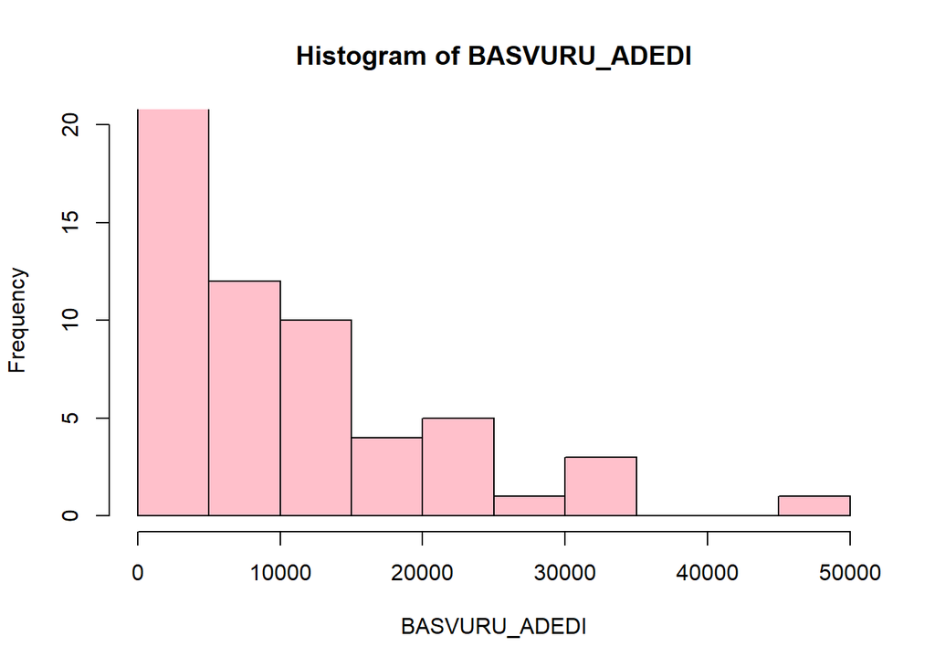

```r
hist(mydata3$BASVURU_ADEDI, main = "Histogram of BASVURU_ADEDI",xlab = "BASVURU_ADEDI" ,col="pink",ylim = c(0,20)) #skewed
```

It is observed that the data is skewed. Applying log transformation would be good for normalizing.

## 16.2 BASVURU_ADEDI Distribution by Gender

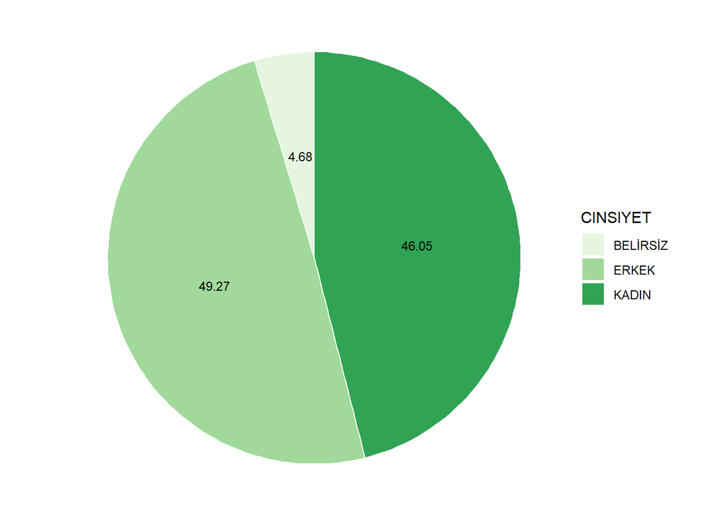

```r
gender_percentage=mydata3 %>% count(CINSIYET)
gender_percentage <- gender_percentage %>%
  arrange(desc(CINSIYET)) %>%
  mutate(prop = format(round(n / sum(gender_percentage$n) *100, 2), nsmall = 2)) %>%
  mutate(ypos = cumsum(n)- 0.5*n )

ggplot(gender_percentage, aes(x="", y=n, fill=CINSIYET)) +
  geom_bar(stat="identity", width=1, color="white") +
  coord_polar("y", start=0) +
  theme_void() +

  geom_text(aes(y = ypos, label = prop), color = "black", size=3) +
  scale_fill_brewer(palette="dark2")
```

## 16.3 BASVURU_SEKLI Distribution

```r
help_percentage=mydata3 %>% count(BASVURU_SEKLI)
help_percentage
```

```
##   BASVURU_SEKLI    n
## 1       DİLEKÇE 8338
## 2    E-BELEDİYE    5
## 3         ESNAF   25
## 4           HİM  390
## 5        MUHTAR  240
## 6 SAHA BAŞVURU   337
```

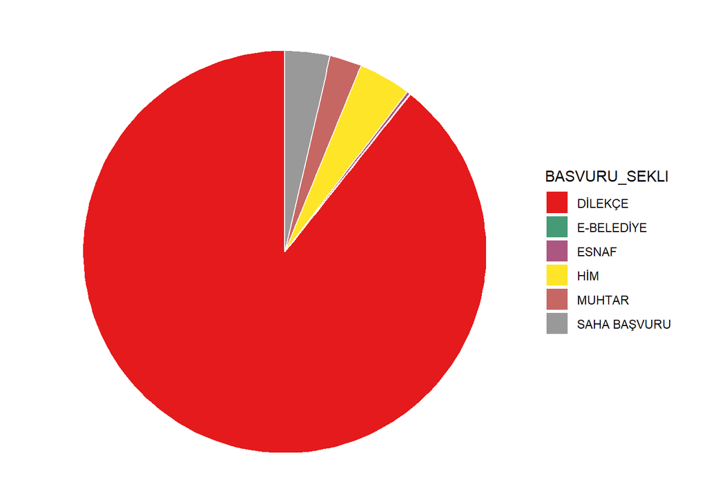

```r
help_percentage <- help_percentage %>%
  arrange(desc(BASVURU_SEKLI)) %>%
  mutate(prop = format(round(n / sum(help_percentage$n) *100, 2), nsmall = 2)) %>%
  mutate(ypos = cumsum(n)- 0.5*n )

 getPalette = colorRampPalette(brewer.pal(9, "Set1"))
 colourCount = length(unique(mydata3$BASVURU_SEKLI))

ggplot(help_percentage, aes(x="", y=n, fill=BASVURU_SEKLI)) +
  geom_bar(stat="identity", width=1, color="white") +
  coord_polar("y", start=0) +
  theme_void() +
  scale_fill_manual(values = getPalette(colourCount))
```

## 16.4 Number of applications according to the BASVURU_SEKLI

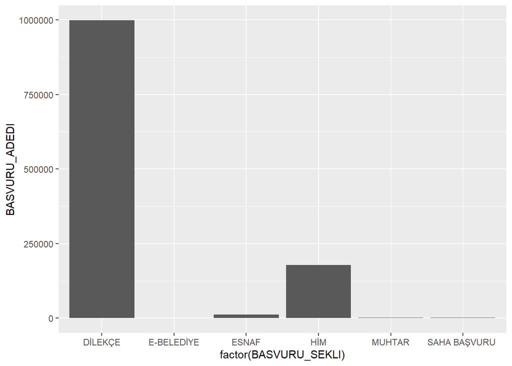

```r
ggplot(mydata3,aes(x=factor(BASVURU_SEKLI), y=BASVURU_ADEDI))+
  geom_bar(stat="identity")
```

It is observed that most of the applications are made by petition.

## 16.5 BASVURU_TIPI Distribution

```r
help_percentage=mydata3 %>% count(BASVURU_TIPI)
help_percentage
```

```
##               BASVURU_TIPI    n
## 1           ÇÖLYAK HASTASI  352
## 2     DENETİMLİ SERBESTLİK  321
## 3               DEPREMZEDE  312
## 4               DOĞAL AFET  132
## 5  DOĞAL AFET (KAR YAĞIŞI)   36
## 6               ENGELLILER 2203
## 7    FENİLKETONÜRİ HASTASI  107
## 8                    KURUM   32
## 9                     OKUL   31
## 10                 PANDEMİ   55
## 11                 SELZEDE  386
## 12  ŞEHIT VE GAZI AILELERI  771
## 13                VATANDAŞ 2534
## 14         YABANCI UYRUKLU  217
## 15              YANGINZEDE  568
## 16                YAŞLILAR 1278
```

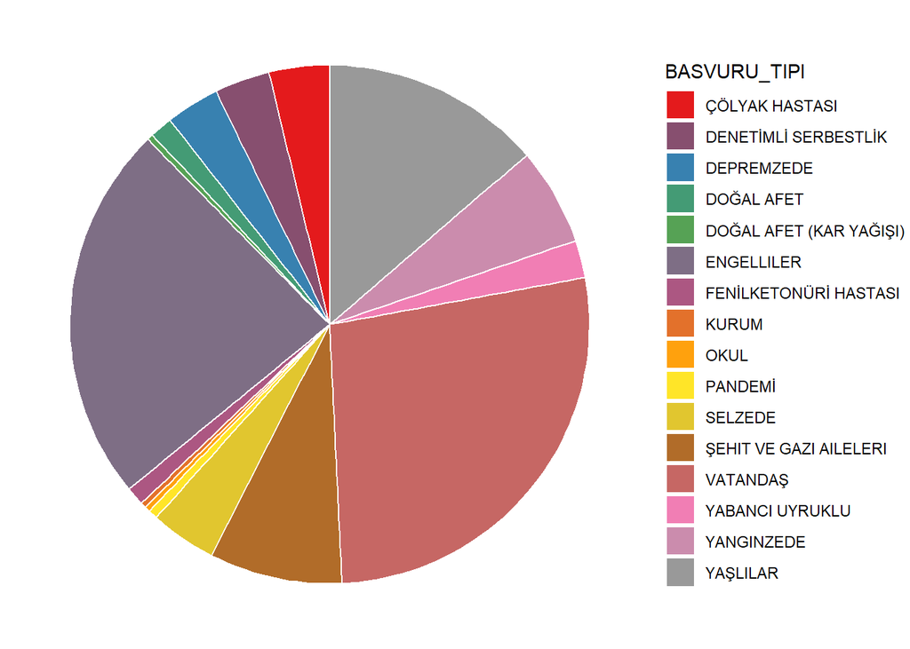

```r
help_percentage <- help_percentage %>%
  arrange(desc(BASVURU_TIPI)) %>%
  mutate(prop = format(round(n / sum(help_percentage$n) *100, 2), nsmall = 2)) %>%
  mutate(ypos = cumsum(n)- 0.5*n )

 getPalette = colorRampPalette(brewer.pal(9, "Set1"))
 colourCount = length(unique(mydata3$BASVURU_TIPI))

ggplot(help_percentage, aes(x="", y=n, fill=BASVURU_TIPI)) +
  geom_bar(stat="identity", width=1, color="white") +
  coord_polar("y", start=0) +
  theme_void() +
  scale_fill_manual(values = getPalette(colourCount))
```

It is observed that the application type mostly belongs to the category of citizens and the disabled.

## 16.6 Number of applications according to the BASVURU_TIPI

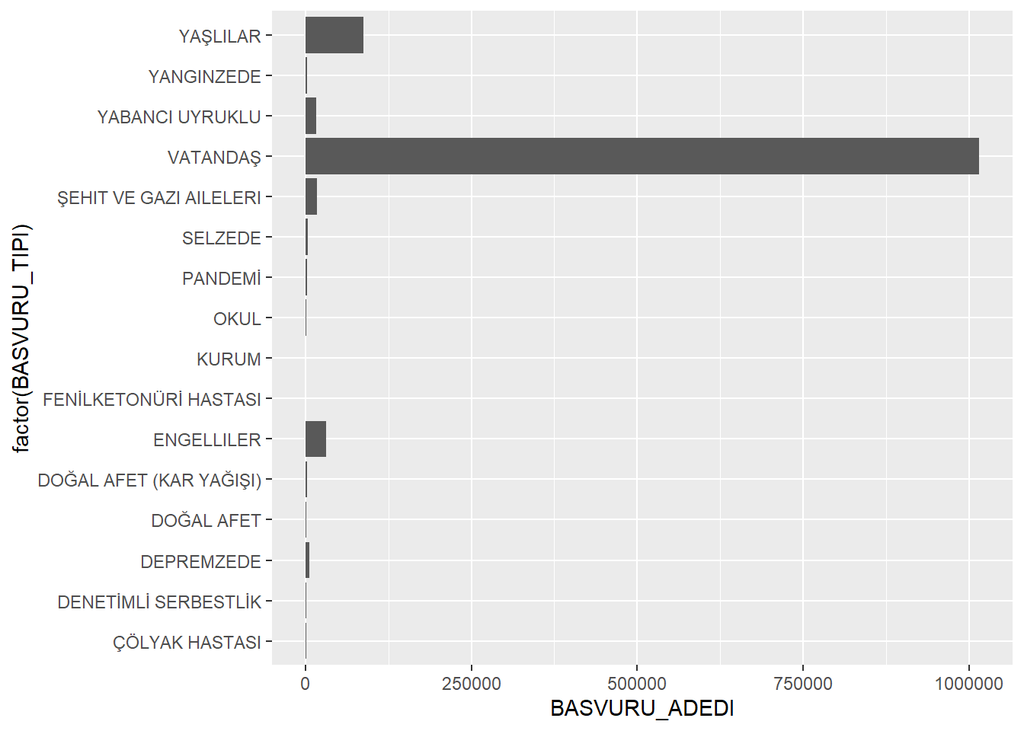

```r
ggplot(mydata3,aes(x=BASVURU_ADEDI, y=factor(BASVURU_TIPI)))+
  geom_bar(stat="identity")
```

It has been observed that most of the applications are made in the citizen type.

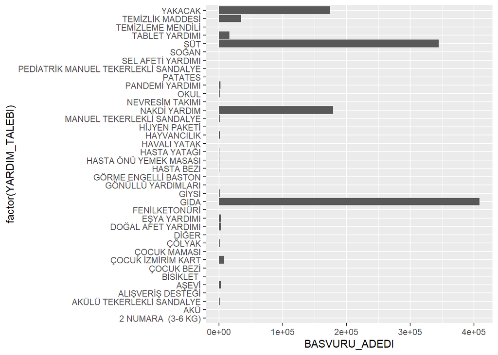

```r
ggplot(mydata3,aes(x=BASVURU_ADEDI, y=factor(YARDIM_TALEBI)))+
  geom_bar(stat="identity")
```

Most aid requests came from the basic needs category such as food and milk.

## 16.8 Year Distribution

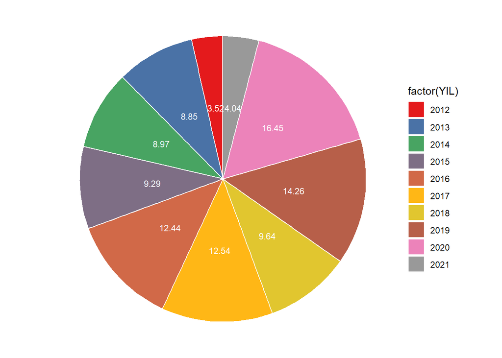

```r
year_percentage=mydata3 %>% count(YIL)
year_percentage <- year_percentage %>%
  arrange(desc(YIL)) %>%
  mutate(prop = format(round(n / sum(year_percentage$n) *100, 2), nsmall = 2)) %>%
  mutate(ypos = cumsum(n)- 0.5*n )

 getPalette = colorRampPalette(brewer.pal(9, "Set1"))
 colourCount = length(unique(mydata3$YIL))

ggplot(year_percentage, aes(x="", y=n, fill=factor(YIL))) +
  geom_bar(stat="identity", width=1, color="white") +
  coord_polar("y", start=0) +
  theme_void() +
  geom_text(aes(y = ypos, label = prop), color = "white", size=3) +
  scale_fill_manual(values = getPalette(colourCount))
```

It is observed that applications are made more frequently in 2020 and 2019.

# 17 Confidance Intervals - Dataset 3

## 17.1 Confidance Interval Between Years according to BASVURU_ADEDI

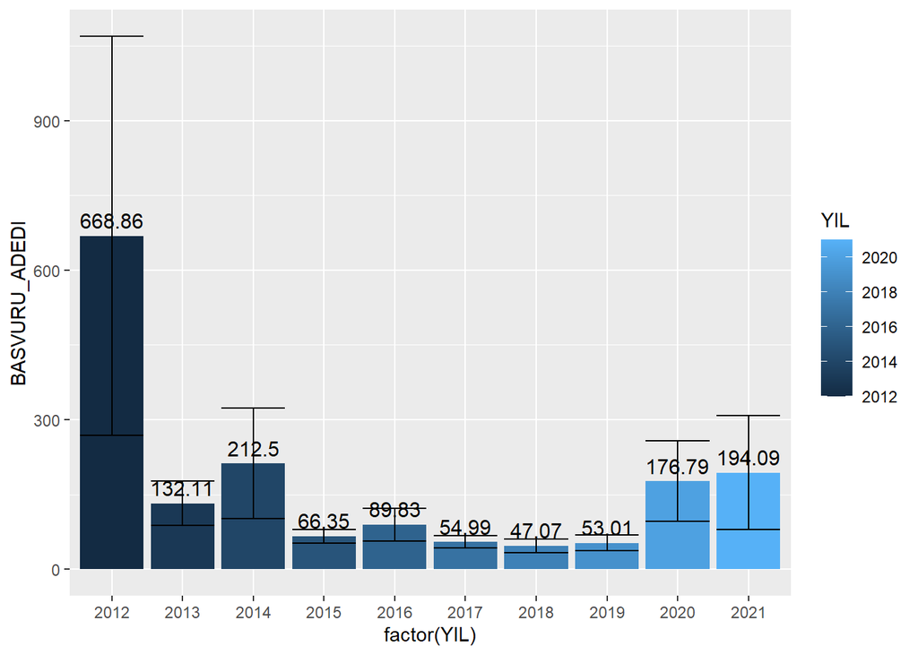

```r
ggplot(mydata3, aes(factor(YIL), BASVURU_ADEDI, fill=YIL)) +
    stat_summary(fun = mean, geom = "bar") +
    stat_summary(aes(label=round(..y..,2)), fun=mean, geom="text", size=4, vjust = -0.5) +
    stat_summary(fun.data = mean_cl_normal, geom = "errorbar")
```

Data for 2012 seem more unreliable.

## 17.2 Confidance Interval Between Genders

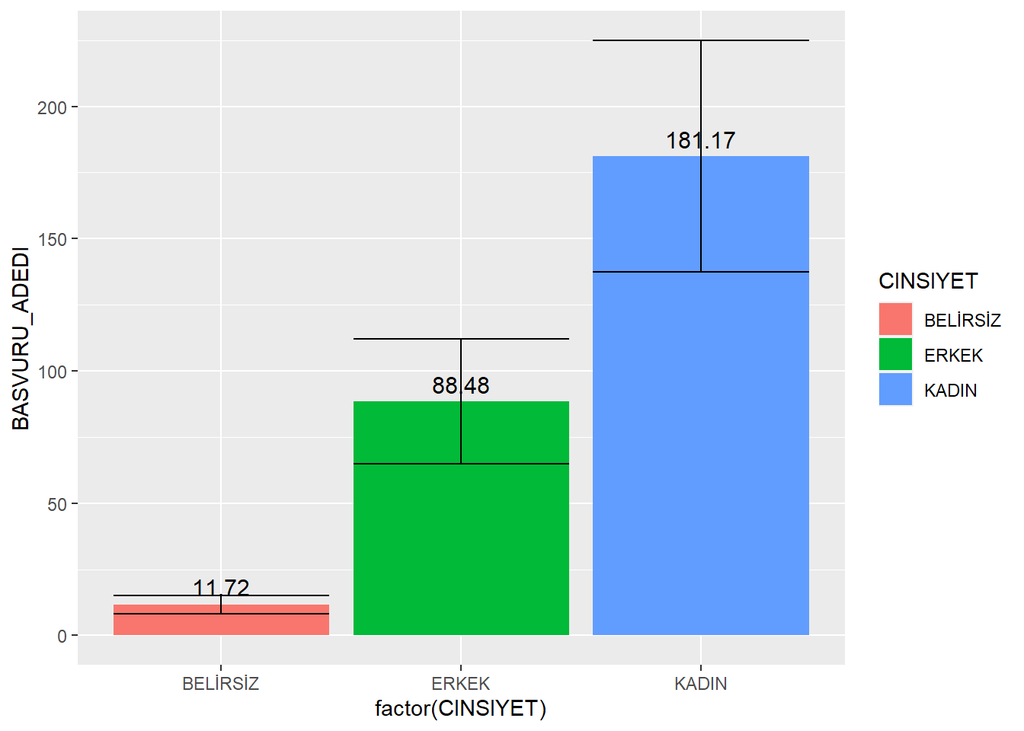

```r
ggplot(mydata3, aes(factor(CINSIYET), BASVURU_ADEDI, fill=CINSIYET)) +
    stat_summary(fun = mean, geom = "bar") +
    stat_summary(aes(label=round(..y..,2)), fun=mean, geom="text", size=4, vjust = -0.5) +
    stat_summary(fun.data = mean_cl_normal, geom = "errorbar")
```

# 18 Normalization - Dataset 3

We used the shapiro wilk test to test for normality in previous data. But now we use the Anderson-Darling normality test because the dataset is large.

```r
ad.test(mydata3$BASVURU_ADEDI) # p-value < 2.2e-16
```

```
##
##  Anderson-Darling normality test
##
## data:  mydata3$BASVURU_ADEDI
## A = 3069, p-value < 2.2e-16
```

### 18.1.2 Log Transformation

```r
mydata3 <- mydata3 %>%
  mutate(log_BASVURU_ADEDI = log(BASVURU_ADEDI))
```

# 19 Hypothesis Tests - Dataset 3

## 19.1 Are there significant difference between mean BASVURU_ADEDI of 2019 and 2020 years?

**H0:** There is no significant difference between mean BASVURU_ADEDI of 2019 and 2020 years.

**H1:** There is significant difference between mean BASVURU_ADEDI of 2019 and 2020 years.

```r
t.test(mydata3$log_BASVURU_ADEDI[mydata3$YIL == 2020], mydata3$log_BASVURU_ADEDI[mydata3$YIL == 2019], data = mydata3, var.equal = TRUE)
```

```
##
##  Two Sample t-test
##
## data:  mydata3$log_BASVURU_ADEDI[mydata3$YIL == 2020] and mydata3$log_BASVURU_ADEDI[mydata3$YIL == 2019]
## t = 0.14327, df = 2865, p-value = 0.8861
## alternative hypothesis: true difference in means is not equal to 0
## 95 percent confidence interval:
##  -0.1237683  0.1432808
## sample estimates:
## mean of x mean of y
##  1.478501  1.468744
```

The p-value of the test is 0.8861, which is more than the significance level alpha = 0.05. And it covers confidence interval 0. This means that there are cases where these two values are close to each other. That is, we fail while rejecting the H0 hypothesis. We can conclude that there is no difference between mean BASVURU_ADEDI of 2019 and 2020 years.

# 20 Anova Part - Dataset 3

## 20.1 Do the number of applications change according to years?

**H0:** The number of applications do not change according to years.

**H0:** µ1 = µ2 = µ3 = µ4 = µ5 = µ6 = µ7 = µ8 = µ9 = µ10

**H1:** The µ<sub>i</sub> are not all equal.

We check if the data is categorical and plot a boxplot graph.

```r
mydata3$YIL = as.factor(mydata3$YIL)
is.factor(mydata3$YIL) #true
```

```
## [1] TRUE
```

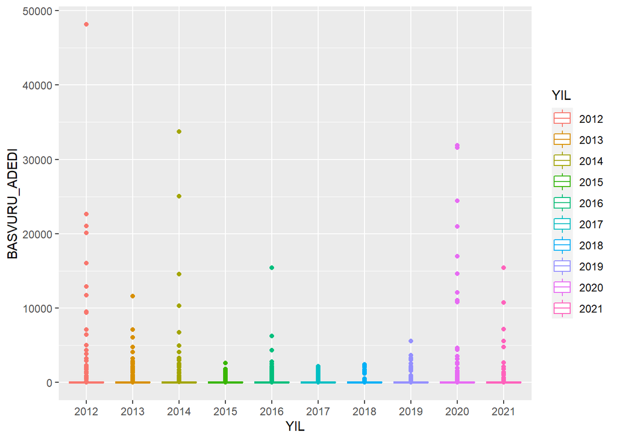

```r
ggplot(mydata3, aes(YIL,BASVURU_ADEDI))+geom_boxplot(aes(col=YIL))
```

Since the data is categorical, we can do ANOVA.

**Anova test:**

```r
model3 = aov(mydata3$BASVURU_ADEDI ~ mydata3$YIL)
summary(model3)
```

```
##               Df    Sum Sq  Mean Sq F value Pr(>F)
## mydata3$YIL    9 1.321e+08 14682310   11.24 <2e-16 ***
## Residuals   9325 1.218e+10  1305723
## ---
## Signif. codes:  0 '***' 0.001 '**' 0.01 '*' 0.05 '.' 0.1 ' ' 1
```

**Tukey Test:** With this test, we detect variables that differ significantly.

```r
TukeyHSD(model3, conf.level = 0.95)
```

```
##   Tukey multiple comparisons of means
##     95% family-wise confidence level
##
## Fit: aov(formula = mydata3$BASVURU_ADEDI ~ mydata3$YIL)
##
## $`mydata3$YIL`
##                  diff        lwr           upr     p adj
## 2013-2012 -536.751224 -772.48809 -301.01435431 0.0000000
## 2014-2012 -456.357196 -691.65241 -221.06198386 0.0000000
## 2015-2012 -602.510701 -836.65446 -368.36694362 0.0000000
## 2016-2012 -579.025557 -804.86696 -353.18415186 0.0000000
## 2017-2012 -613.865306 -839.49369 -388.23692630 0.0000000
## 2018-2012 -621.793516 -854.75345 -388.83358432 0.0000000
## 2019-2012 -615.846659 -838.48069 -393.21262279 0.0000000
## 2020-2012 -492.073724 -711.74352 -272.40392475 0.0000000
## 2021-2012 -474.769997 -747.57870 -201.96129521 0.0000017
## 2014-2013   80.394028  -96.95053  257.73858507 0.9165446
## 2015-2013  -65.759478 -241.57346  110.05449939 0.9749474
## 2016-2013  -42.274334 -206.86958  122.32091425 0.9984142
## 2017-2013  -77.114083 -241.41692   87.18875085 0.8983622
## 2018-2013  -85.042292 -259.27657   89.19198953 0.8741166
## 2019-2013  -79.095435 -239.26150   81.07063251 0.8660526
## 2020-2013   44.677499 -111.34197  200.69697267 0.9963217
## 2021-2013   61.981227 -162.76717  286.72962593 0.9972417
## 2015-2014 -146.153506 -321.37485   29.06783903 0.1993594
## 2016-2014 -122.668362 -286.63043   41.29370939 0.3456713
## 2017-2014 -157.508111 -321.17664    6.16041475 0.0708751
## 2018-2014 -165.436320 -339.07258    8.19993765 0.0772141
## 2019-2014 -159.489463 -319.00477    0.02584753 0.0500772
## 2020-2014  -35.716529 -191.06788  119.63481884 0.9993443
## 2021-2014  -18.412801 -242.69791  205.87230311 0.9999999
## 2016-2015   23.485144 -138.82020  185.79048433 0.9999865
## 2017-2015  -11.354605 -173.36340  150.65418787 1.0000000
## 2018-2015  -19.282814 -191.35551  152.78988173 0.9999985
## 2019-2015  -13.335957 -171.14786  144.47594667 0.9999999
## 2020-2015  110.436977  -43.16479  264.03874756 0.4053731
## 2021-2015  127.740705  -95.33612  350.81753159 0.7277466
## 2017-2016  -34.839749 -184.59919  114.91969091 0.9992788
## 2018-2016  -42.767959 -203.36078  117.82486094 0.9978949
## 2019-2016  -36.821102 -182.03005  108.38784443 0.9985662
## 2020-2016   86.951833  -53.67016  227.57382559 0.6297248
## 2021-2016  104.255560 -110.09068  318.60180286 0.8764509
## 2018-2017   -7.928210 -168.22131  152.36489459 1.0000000
## 2019-2017   -1.981353 -146.85876  142.89605615 1.0000000
## 2020-2017  121.791582  -18.48803  262.07119690 0.1551377
## 2021-2017  139.095310  -75.02647  353.21709072 0.5592378
## 2019-2018    5.946857 -150.10322  161.99693664 1.0000000
## 2020-2018  129.719792  -22.07130  281.51087879 0.1718438
## 2021-2018  147.023519  -74.81043  368.85746820 0.5294089
## 2020-2019  123.772935  -11.63799  259.18385906 0.1076795
## 2021-2019  141.076662  -69.88752  352.04084221 0.5159324
## 2021-2020   17.303727 -190.52984  225.13729562 0.9999999
```

## 20.2 Do the number of applications change according to genders?

**H0:** The number of applications do not change according to genders.

**H0:** µ1 = µ2 = µ3

**H1:** The µ<sub>i</sub> are not all equal.

```r
mydata3$CINSIYET = as.factor(mydata3$CINSIYET)
is.factor(mydata3$CINSIYET) #true
```

```
## [1] TRUE
```

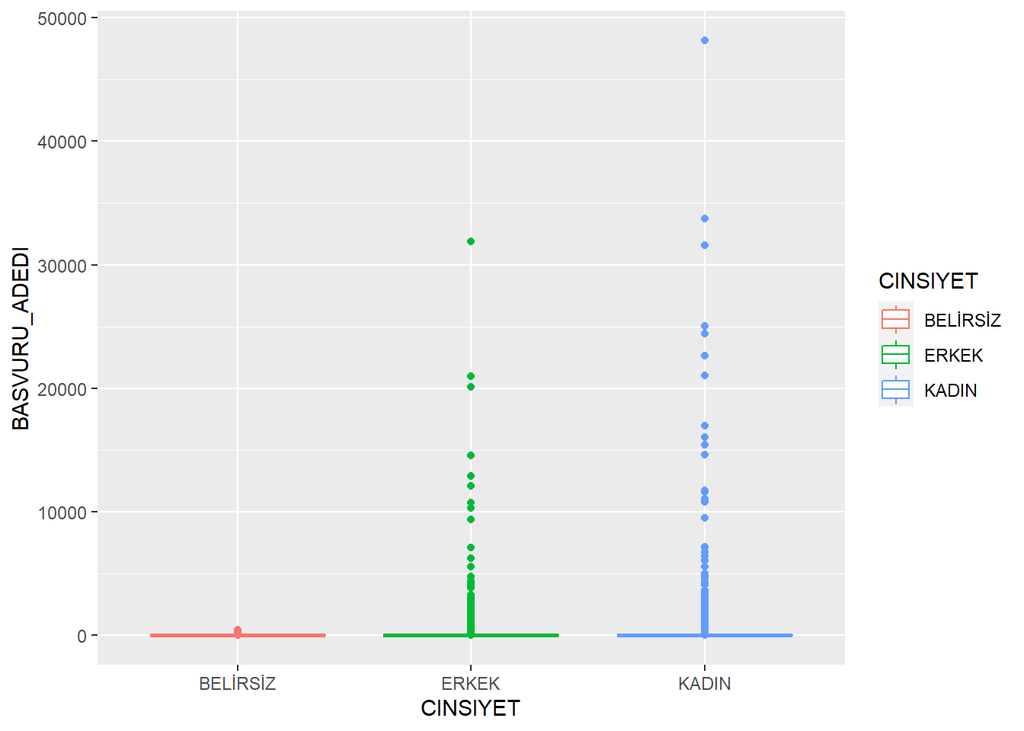

```r
ggplot(mydata3, aes(CINSIYET,BASVURU_ADEDI))+geom_boxplot(aes(col=CINSIYET))
```

Since the data is categorical, we can apply ANOVA.

**Anova test:**

```r
model4 = aov(mydata3$BASVURU_ADEDI ~ mydata3$CINSIYET)
summary(model4)
```

```
##                    Df    Sum Sq  Mean Sq F value   Pr(>F)
## mydata3$CINSIYET    2 2.524e+07 12622112    9.59 6.91e-05 ***
## Residuals        9332 1.228e+10  1316199
## ---
## Signif. codes:  0 '***' 0.001 '**' 0.01 '*' 0.05 '.' 0.1 ' ' 1
```

The P value was less than the significance level. In this case, it would be more correct to reject H0. In other words, the number of applications made is not the same for all genders.

**Tukey Test:**

```r
TukeyHSD(model4, conf.level = 0.95)
```

```
##   Tukey multiple comparisons of means
##     95% family-wise confidence level
##
## Fit: aov(formula = mydata3$BASVURU_ADEDI ~ mydata3$CINSIYET)
##
## $`mydata3$CINSIYET`
##                     diff       lwr      upr     p adj
## ERKEK-BELİRSİZ  76.75656 -57.86132 211.3744 0.3748860
## KADIN-BELİRSİZ 169.44925  34.42440 304.4741 0.0091761
## KADIN-ERKEK     92.69270  35.64172 149.7437 0.0004134
```

As can be seen, there is a significant difference between KADIN-BELİRSİZ pairs and KADIN-ERKEK pairs.

# 21 Discussion

Considering the **effects of the pandemic on social actions**,

**-** it was observed that there was no significant increase in the aid provided by the municipality during the pandemic period.

**-** it has been observed that children go to children and education centers less and there is no significant increase in the number of children receiving psychological support.

# 22 References

[Dataset 1](https://acikveri.bizizmir.com/tr/dataset/yemek-corba-pide-kumanya-destegi/resource/98c11b1c-095f-4135-b7a2-ca0e72a7489c)

[Dataset 2](https://acikveri.bizizmir.com/tr/dataset/cocuk-ve-genclik-merkezleri-cogem/resource/3ea92159-e95b-4149-9d7b-6e9e012955d6)

[Dataset 3](https://acikveri.bizizmir.com/tr/dataset/izmir-buyuksehir-belediyesine-sosyal-yardim-basvurulari/resource/04ad0a96-4931-4491-ba85-a700ac50a7df)